# Laboratorio 1

En este laboratorio elaborado por Juan Esteban Piñeros Barrera - 202412232 y Julian Ramos - 202414411, vamos a trabajar el problema que enfrenta AlpesPlanck, para esto vamos a usar un modelo de regresion lineal a los datos proporcionados por la organizacion. En primer lugar vamos a importar todas las librerias que vamos a estar utilizando en este proceso.

```python
import pandas as pd
import numpy as np
import matplotlib.pyplot as plt
import seaborn as sns

from sklearn.model_selection import train_test_split
from sklearn.pipeline import Pipeline
from sklearn.compose import ColumnTransformer
from sklearn.preprocessing import StandardScaler, OneHotEncoder, FunctionTransformer
from sklearn.impute import SimpleImputer
from sklearn.linear_model import LinearRegression
from sklearn.metrics import mean_squared_error, r2_score, mean_absolute_error
from statsmodels.formula.api import ols

from statsmodels.stats.diagnostic import linear_rainbow
from scipy.stats import ttest_1samp
from statsmodels.stats.stattools import durbin_watson
import statsmodels.api as sm
from statsmodels.stats.diagnostic import het_breuschpagan
import scipy.stats as stats
from statsmodels.stats.outliers_influence import variance_inflation_factor
from scipy.stats import shapiro
```

Importamos todas estas librerias basandonos en las practicas del curso, sobretodo la practica 4.2 que consideramos que es la que contiene todo lo relevante para nuestro laboratorio, aunque si es necesario mas adelante importaremos librerias que nos puedan ser utiles

## 1. Conversion y analisis de datos

En esta seccion vamos a transformar los datos que recibimos en forma de .csv en un DataFrame para poder usarlos y hacer sus respectivos analisis que van a marcar nuestras acciones mas adelante

```python
datos_test = pd.read_csv('data/Datos_Lab1.csv', sep=',')
data = datos_test.copy()
data.head()
```

|  | fecha | presion_media | presion_min | presion_max | presion_desv | humedad_media | humedad_min | humedad_max | humedad_desv | viento_media | ... | viento_norte | viento_este | direccion_viento | registros_del_dia | anio | dia_del_anio | estacion_anio | mes | sector_viento | temp_max_manana |
| --- | --- | --- | --- | --- | --- | --- | --- | --- | --- | --- | --- | --- | --- | --- | --- | --- | --- | --- | --- | --- | --- |
| 0 | 2009-01-01 | 999.1456 | 996.50 | 1000.87 | 1.3993 | 0.910860 | 0.875000 | 94.8 | 1.7650 | 0.7786 | ... | -0.3618 | -0.0223 | 183.5308 | 143.0 | 2009.0 | 1.0 | invierno | January | S | -2.12 |
| 1 | 2009-01-02 | 999.6006 | 997.93 | 1002.65 | 1.5039 | 0.920868 | 86.600000 | 96.3 | 2.7588 | 1.4195 | ... | 0.4267 | 0.3689 | 40.8436 | 144.0 | 2009.0 | 2.0 | invierno | JULY | NE | -0.82 |
| 2 | 2009-01-03 | 998.5486 | 993.05 | 1002.49 | 3.1304 | 76.458100 | 48.390000 | 93.9 | 15.1796 | 1.2509 | ... | -0.6993 | -0.5268 | 216.9916 | 144.0 | 2009.0 | 3.0 | invierno | January | SO | -0.63 |
| 3 | 2009-01-04 | 988.5107 | 985.12 | 992.93 | 2.3223 | 89.417400 | 97.946704 | NaN | 4.4904 | 1.7204 | ... | -1.1268 | -1.0413 | 222.7419 | 144.0 | 2009.0 | 4.0 | invierno | JANUARY | SO | -1.44 |
| 4 | 2009-01-05 | 990.4057 | NaN | 997.54 | 4.2315 | 86.260400 | 74.600000 | 93.2 | 5.3922 | 3.8003 | ... | 2.6275 | 0.2874 | 6.2418 | NaN | 2009.0 | 5.0 | East | January | N | -10.88 |

5 rows × 27 columns

Muy bien, ya cargado el DataFrame vamos a verificar como se ven los datos para tener una idea clara de con que vamos a estar trabajando

En primer lugar vamos a ver como se ven 10 datos aleatorios de nuestro dataframe

```python
display(data.sample(10))
```

|  | fecha | presion_media | presion_min | presion_max | presion_desv | humedad_media | humedad_min | humedad_max | humedad_desv | viento_media | ... | viento_norte | viento_este | direccion_viento | registros_del_dia | anio | dia_del_anio | estacion_anio | mes | sector_viento | temp_max_manana |
| --- | --- | --- | --- | --- | --- | --- | --- | --- | --- | --- | --- | --- | --- | --- | --- | --- | --- | --- | --- | --- | --- |
| 1898 | 2014-03-14 | 997.3494 | 990.020000 | 1001.20 | 3.5885 | 0.652675 | 0.363900 | 92.70 | NaN | 3.85272 | ... | -0.5508 | 0.1854 | 161.3973 | 144.0 | 2014.0 | 73.0 | primavera | Apr | S | 11.35 |
| 1044 | NaN | 1001.2067 | 998.970000 | 1002.94 | 1.1959 | 86.210600 | 68.550000 | 100.00 | 9.3832 | 8.17344 | ... | -0.0896 | 1.5304 | 93.3508 | 144.0 | 2011.0 | 315.0 | otono | JANUARY | East | 7.68 |
| 2525 | 2015-12-01 | 993.6853 | 983.470000 | 998.34 | 4.8608 | 0.824587 | 68.790000 | 97.90 | 9.4463 | 1.55150 | ... | -0.5002 | -0.9965 | 243.3458 | 144.0 | 2015.0 | 335.0 | invierno | Apr | SO | 10.58 |
| 843 | 2011-04-24 | 990.3650 | 987.550000 | 993.16 | 1.5824 | 48.513300 | 33.160000 | 70.00 | 10.8453 | 2.69150 | ... | 1.8522 | 1.6875 | 42.3353 | 144.0 | 2011.0 | 114.0 | primavera | February | NE | 16.26 |
| 1866 | 2014-02-10 | 972.4695 | 969.150000 | 975.95 | 2.5855 | 0.679161 | 0.422600 | 91.00 | 16.9740 | 2.34870 | ... | -2.1626 | -0.2027 | 185.3554 | NaN | 2014.0 | 41.0 | invierno | julio | S | 6.74 |
| 239 | 2009-08-28 | 985.9072 | 991.038942 | 983.67 | 1.5138 | 63.180400 | 96.482536 | 41.45 | 18.1756 | 2.72850 | ... | -2.0019 | -1.5179 | 217.1710 | 144.0 | 2009.0 | 240.0 | verno | August | Suroeste | 18.67 |
| 1152 | 2012-02-27 | 997.4844 | 994.880000 | 999.18 | 1.5090 | 79.137800 | 56.290000 | 95.20 | 12.4602 | 1.27560 | ... | -0.7282 | NaN | 225.4318 | 144.0 | 2012.0 | 58.0 | verano | mayo | SO | 9.41 |
| 67 | 2009-03-09 | 980.0093 | 975.240000 | 984.44 | 3.0705 | 74.428500 | 56.690000 | 97.00 | 11.2405 | NaN | ... | -1.3009 | -2.1577 | 238.9135 | 144.0 | 2009.0 | 68.0 | primavera | junio | SO | 5.58 |
| 2014 | NaN | 980.6437 | 977.670000 | 986.32 | 2.4329 | 0.933688 | 0.878000 | 97.20 | 2.5686 | 2.42580 | ... | 1.5491 | 0.6172 | 21.7236 | 144.0 | 2014.0 | 189.0 | Inverano | Dec | N | 16.59 |
| 2423 | 2015-08-21 | 998.4950 | 997.090000 | 1000.02 | NaN | NaN | 37.610000 | 99.30 | 24.5984 | 4.60764 | ... | 0.2505 | 0.3993 | 57.8943 | 144.0 | 2015.0 | 233.0 | invierno | Aug | NE | 24.13 |

10 rows × 27 columns

Tambien vamos a verificar el tamaño de nuestro Dataframe

```python
data.shape
```

```
(2576, 27)
```

Una vez cargado nuestro Dataframe vamos a revisar los tipos de datos, que en conjunto con el diccionario, nos van a ayudar a decidir que variables son cuantitativas y cuales son cualitativas.

```python
data.info()
```

```
<class 'pandas.core.frame.DataFrame'>
RangeIndex: 2576 entries, 0 to 2575
Data columns (total 27 columns):
 #   Column             Non-Null Count  Dtype
---  ------             --------------  -----
 0   fecha              2504 non-null   object
 1   presion_media      2501 non-null   float64
 2   presion_min        2502 non-null   float64
 3   presion_max        2512 non-null   float64
 4   presion_desv       2496 non-null   float64
 5   humedad_media      2502 non-null   float64
 6   humedad_min        2496 non-null   float64
 7   humedad_max        2490 non-null   float64
 8   humedad_desv       2515 non-null   float64
 9   viento_media       2490 non-null   float64
```

[output cut: 19 more lines]

Tambien vamos a cargar nuestro diccionario para tener claro cual es el rol de cada variable y asi saber exactamente que tipo de variable es (ordinal, cardinal, etc.)

```python
dict = pd.read_excel('data/Diccionario de datos.xlsx')
pd.set_option('display.max_colwidth', None)
dict
```

|  | variable | tipo | descripcion |
| --- | --- | --- | --- |
| 0 | fecha | texto | Fecha de la observación, en formato día.mes.año. |
| 1 | presion_media | numérico | Presión atmosférica media del día (mbar). |
| 2 | presion_min | numérico | Presión atmosférica mínima del día (mbar). |
| 3 | presion_max | numérico | Presión atmosférica máxima del día (mbar). |
| 4 | presion_desv | numérico | Desviación típica de la presión durante el día (mbar). |
| 5 | humedad_media | numérico | Humedad relativa media del día (%). |
| 6 | humedad_min | numérico | Humedad relativa mínima del día (%). |
| 7 | humedad_max | numérico | Humedad relativa máxima del día (%). |
| 8 | humedad_desv | numérico | Desviación típica de la humedad relativa (%). |
| 9 | viento_media | numérico | Velocidad media del viento durante el día (m/s). |
| 10 | viento_min | numérico | Velocidad mínima del viento registrada en el día (m/s). |
| 11 | viento_max | numérico | Velocidad máxima del viento registrada en el día (m/s). |
| 12 | viento_desv | numérico | Desviación típica de la velocidad del viento (m/s). |
| 13 | rafaga_media | numérico | Media de las ráfagas máximas registradas (m/s). |
| 14 | rafaga_min | numérico | Mínima de las ráfagas máximas registradas (m/s). |
| 15 | rafaga_max | numérico | Ráfaga más fuerte del día (m/s). |
| 16 | rafaga_desv | numérico | Desviación típica de las ráfagas (m/s). |
| 17 | viento_norte | numérico | Componente norte-sur del viento medio del día (m/s). |
| 18 | viento_este | numérico | Componente este-oeste del viento medio del día (m/s). |
| 19 | direccion_viento | numérico | Dirección media del viento durante el día, en grados de 0 a 360. |
| 20 | registros_del_dia | numérico | Número de mediciones de 10 minutos que se resumieron para formar esta fila. Un día completo tiene 144. |
| 21 | anio | numérico | Año de la observación. |
| 22 | dia_del_anio | numérico | Día del año, de 1 a 366. |
| 23 | estacion_anio | texto | Estación del año: invierno, primavera, verano u otoño. |
| 24 | mes | texto | Mes de la observación. |
| 25 | sector_viento | texto | Sector de la rosa de los vientos hacia el que sopló el viento medio del día: N, NE, E, SE, S, SO, O, NO. |
| 26 | temp_max_manana | numérico | VARIABLE OBJETIVO: temperatura máxima del día siguiente, en grados Celsius. |

Muy bien, ya visto nuestro diccionario y los tipo de datos vamos a dividir las variables cuantitativas entre discretas y continuas, y a las cualitativas entre ordinales y nominales.

```python
cuantitativas_discretas =  ['registros_del_dia', 'dia_del_anio','anio']
cuantitativas_continuas = ['direccion_viento', 'presion_media', 'presion_min', 'presion_max', 'presion_desv', 'humedad_media', 'humedad_min', 'humedad_max', 'humedad_desv', 'viento_media', 'viento_min', 'viento_max', 'viento_desv', 'rafaga_media', 'rafaga_min', 'rafaga_max', 'rafaga_desv', 'viento_norte', 'viento_este', 'temp_max_manana']
cualitativas_ordinales = ['mes', 'estacion_anio']
cualitativas_nominales = ['fecha', 'sector_viento']
```

Dejamos mes y la estacion en ordinales, ya que entre los meses y las estaciones hay un orden (primavera -> verano -> otoño -> invierno), aunque probablemente mas adelante alguna de estas 2, si no es que las dos, van a ser eliminadas ya que por simple intuicion lo mas probable es que vayan a tener un VIF infinito, por lo cual deben ser eliminadas.

Antes de continuar, vamos a transformar las variables de tiempo a un formato que podamos trabajar con ellas en el dataset

```python
data['fecha'] = pd.to_datetime(data['fecha'], format='%Y-%m-%d')
data.info()
```

```
<class 'pandas.core.frame.DataFrame'>
RangeIndex: 2576 entries, 0 to 2575
Data columns (total 27 columns):
 #   Column             Non-Null Count  Dtype
---  ------             --------------  -----
 0   fecha              2504 non-null   datetime64[ns]
 1   presion_media      2501 non-null   float64
 2   presion_min        2502 non-null   float64
 3   presion_max        2512 non-null   float64
 4   presion_desv       2496 non-null   float64
 5   humedad_media      2502 non-null   float64
 6   humedad_min        2496 non-null   float64
 7   humedad_max        2490 non-null   float64
 8   humedad_desv       2515 non-null   float64
 9   viento_media       2490 non-null   float64
```

[output cut: 19 more lines]

Por ultimo antes de avanzar en las correciones de los datos vamos a ver las principales medidas estadisticas de las variables numericas

```python
data.describe()
```

|  | fecha | presion_media | presion_min | presion_max | presion_desv | humedad_media | humedad_min | humedad_max | humedad_desv | viento_media | ... | rafaga_min | rafaga_max | rafaga_desv | viento_norte | viento_este | direccion_viento | registros_del_dia | anio | dia_del_anio | temp_max_manana |
| --- | --- | --- | --- | --- | --- | --- | --- | --- | --- | --- | --- | --- | --- | --- | --- | --- | --- | --- | --- | --- | --- |
| count | 2504 | 2501.000000 | 2502.000000 | 2512.000000 | 2496.000000 | 2502.000000 | 2496.000000 | 2490.000000 | 2515.000000 | 2490.000000 | ... | 2504.000000 | 2503.000000 | 2497.000000 | 2496.000000 | 2512.000000 | 2497.000000 | 2499.000000 | 2490.000000 | 2508.000000 | 2481.000000 |
| mean | 2012-06-29 14:19:10.159744512 | 1010.494271 | 986.684409 | 991.704244 | 1.752041 | 52.413586 | 45.094067 | 90.236582 | 10.606821 | 3.814103 | ... | -2.639322 | 6.946058 | -5.763253 | -1.128463 | -0.410159 | 172.104573 | 144.090836 | 2011.995582 | 182.690989 | 13.863309 |
| min | 2009-01-01 00:00:00 | 948.996000 | 913.600000 | 951.940000 | 0.226900 | 0.004663 | 0.237700 | 27.020000 | 0.000000 | 0.000000 | ... | -9999.000000 | 0.000000 | -232.260000 | -1250.463300 | -3.718500 | 0.000000 | 90.000000 | 2009.000000 | 1.000000 | -15.230000 |
| 25% | 2010-09-22 18:00:00 | 984.287800 | 981.371333 | 987.070000 | 0.899050 | 0.869060 | 1.011790 | 88.025000 | 6.082100 | 1.655350 | ... | 0.440000 | 4.803198 | 1.002100 | -1.640625 | -1.236475 | 91.303500 | 144.000000 | 2010.000000 | 91.000000 | 7.310000 |
| 50% | 2012-07-04 12:00:00 | 989.452800 | 987.070000 | 991.935000 | 1.444550 | 68.558100 | 49.670000 | 93.300000 | 10.199800 | 2.463400 | ... | 0.660000 | 6.690000 | 1.461100 | -0.564300 | -0.356000 | 199.568500 | 144.000000 | 2012.000000 | 182.500000 | 14.310000 |
| 75% | 2014-03-30 06:00:00 | 994.469000 | 992.567500 | 996.782500 | 2.254800 | 80.562600 | 67.665000 | 96.600000 | 14.722200 | 4.880505 | ... | 1.120000 | 8.850000 | 2.008800 | 0.241525 | 0.316275 | 227.101700 | 144.000000 | 2014.000000 | 274.250000 | 20.460000 |
| max | 2015-12-31 00:00:00 | 9939.918000 | 1012.320198 | 1013.940000 | 12.397500 | 100.000000 | 103.311405 | 100.000000 | 26.341600 | 24.753600 | ... | 19.895916 | 23.500000 | 3471.027800 | 4.809900 | 4.713900 | 359.796700 | 287.000000 | 2015.000000 | 366.000000 | 63.050000 |
| std | NaN | 435.334494 | 8.927138 | 7.726906 | 1.215931 | 35.975384 | 30.196163 | 10.647237 | 5.481338 | 3.307402 | ... | 199.861693 | 3.237379 | 75.258134 | 25.065084 | 1.147218 | 86.102348 | 4.107365 | 1.999694 | 105.529469 | 9.296199 |

8 rows × 24 columns

### Analisis visual de variables numéricas y valores atípicos

Antes de continuar con la limpieza de las variables categóricas, complementamos las estadísticas descriptivas anteriores con gráficas que permiten identificar valores atípicos y entender mejor la distribución de las variables numéricas.

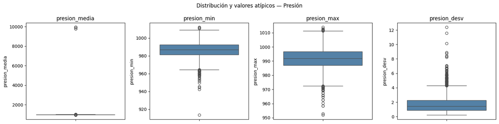

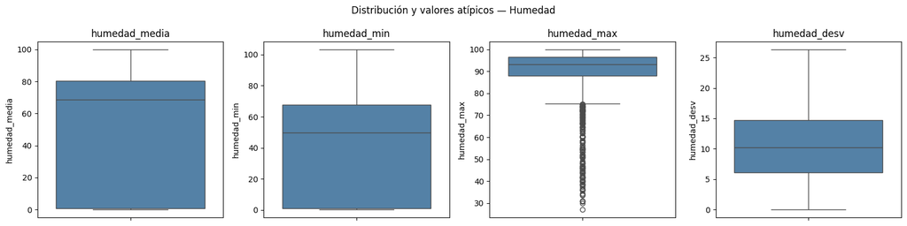

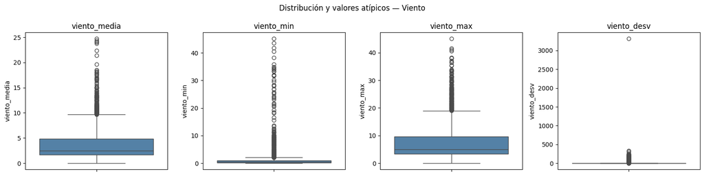

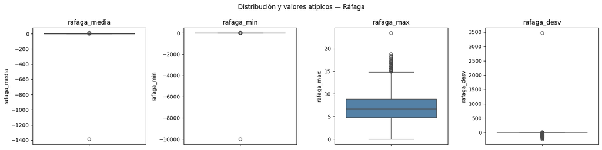

```python
grupos_vars = {
    'Presión': ['presion_media', 'presion_min', 'presion_max', 'presion_desv'],
    'Humedad': ['humedad_media', 'humedad_min', 'humedad_max', 'humedad_desv'],
    'Viento': ['viento_media', 'viento_min', 'viento_max', 'viento_desv'],
    'Ráfaga': ['rafaga_media', 'rafaga_min', 'rafaga_max', 'rafaga_desv'],
}

for nombre, cols in grupos_vars.items():
    fig, axes = plt.subplots(1, len(cols), figsize=(16, 4))
    for ax, col in zip(axes, cols):
        sns.boxplot(y=data[col], ax=ax, color='steelblue')
        ax.set_title(col)
    fig.suptitle(f'Distribución y valores atípicos — {nombre}')
    plt.tight_layout()
    plt.show()
```

Los boxplots muestran presencia de valores atípicos en varias variables, especialmente en las de dispersión (`_desv`) y en los máximos/mínimos, lo cual es consistente con los problemas de validez que identificamos y corregimos más adelante (columnas invertidas, valores centinela, errores de escala). Estos gráficos confirman visualmente por qué esa etapa de corrección fue necesaria.

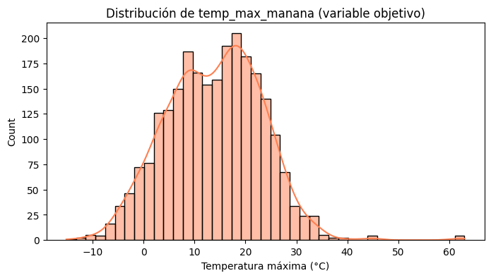

```python
plt.figure(figsize=(8, 4))
sns.histplot(data['temp_max_manana'].dropna(), kde=True, color='coral')
plt.title('Distribución de temp_max_manana (variable objetivo)')
plt.xlabel('Temperatura máxima (°C)')
plt.show()
```

La variable objetivo `temp_max_manana` muestra una distribución razonablemente simétrica, sin señales fuertes de sesgo que ameriten una transformación antes de usarla en el modelo de regresión lineal.

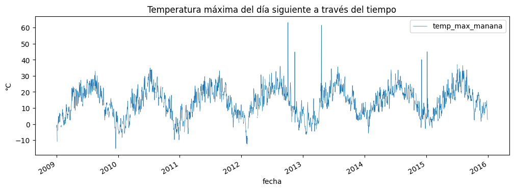

```python
plt.figure(figsize=(12, 4))
data.sort_values('fecha').plot(x='fecha', y='temp_max_manana', ax=plt.gca(), linewidth=0.5)
plt.title('Temperatura máxima del día siguiente a través del tiempo')
plt.ylabel('°C')
plt.show()
```

La serie de tiempo evidencia claramente el patrón estacional cíclico de la temperatura a lo largo de los años — un ciclo que, como se discute más adelante en la construcción de los pipelines, es mejor capturado por una variable categórica (`mes`) que por una relación lineal simple con `dia_del_anio`.

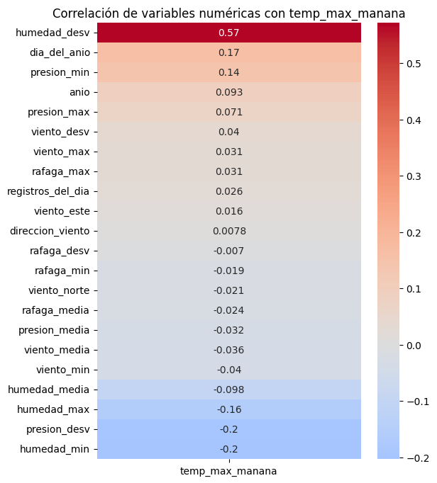

```python
numericas = data.select_dtypes(include='number').columns
corr_target = data[numericas].corr()['temp_max_manana'].drop('temp_max_manana').sort_values(ascending=False)

plt.figure(figsize=(6, 8))
sns.heatmap(corr_target.to_frame(), annot=True, cmap='coolwarm', center=0)
plt.title('Correlación de variables numéricas con temp_max_manana')
plt.show()
```

(Estos graficos se realizaron despues de acabar todo el ejercicio, nos dimos cuenta por la rubrica que nos falta explicar mejor esta parte)

En esta nueva seccion vamos a explorar los valores que toman las variables cualitativas o de texto para limpiarlos y dejarlos listo para sus respectivas transformaciones numericas.

```python
# Descripción de columnas cualitativas (tipo object)
data.describe(include='object')
```

|  | estacion_anio | mes | sector_viento |
| --- | --- | --- | --- |
| count | 2488 | 2488 | 2505 |
| unique | 28 | 61 | 33 |
| top | primavera | May | SO |
| freq | 517 | 127 | 695 |

Vemos que tenemos bastante trabajo por delante dado que si nos fijamos en el apartado de unique tenemos valores muy altos para las 3 variables en formato de texto, para esto vamos a revisar una por una los valores que estas tomando para corregir y facilitar las siguientes partes del trabajo

```python
print("Valores únicos en estacion_anio:")
print(data['estacion_anio'].unique())
print(f"Total de valores únicos: {data['estacion_anio'].nunique()}")
data['estacion_anio'].value_counts(dropna=False)
```

```
Valores únicos en estacion_anio:
['invierno' 'East' nan 'Estacion_Desconocida' 'verano' 'Inverano'
 'invierno ' 'INVIERNO' 'VERANO_INVIERNO' 'Verano' 'primavera' 'Primavera'
 'primaveraa' 'PRIMAVERA' 'berano' 'VERANO' 'verno' 'otono' 'otoño '
 'fall' 'autumn' 'OTONO' 'winter' 'invernio' 'primav' 'spring' 'Otoño'
 'Invierno' 'summer']
Total de valores únicos: 28
```

```
estacion_anio
primavera               517
invierno                511
otono                   500
verano                  487
NaN                      88
Inverano                 71
Estacion_Desconocida     63
VERANO_INVIERNO          60
East                     48
VERANO                   19
autumn                   18
berano                   17
primaveraa               17
fall                     15
winter                   15
verno                    14
Otoño                    12
invernio                 11
otoño                    11
PRIMAVERA                10
Primavera                10
Verano                    9
INVIERNO                  9
invierno                  9
Invierno                  9
OTONO                     8
primav                    6
spring                    6
summer                    6
Name: count, dtype: int64
```

En primer lugar vamos a arreglar las estaciones que sean faciles de saber a que se refieren, es decir, las que se notan que el problema es una letra, mayuscula(s) o error de digitacion. Aun no vamos a trabajar en corregir cosas como VERANO_INVIERNO, East, Estacion_Desconocida, etc. Dado que estas se deben trabajar de manera diferente.

```python
mapa = {
    # invierno
    'invierno': 'invierno', 'invierno ': 'invierno', 'INVIERNO': 'invierno','Invierno': 'invierno','winter': 'invierno', 'invernio': 'invierno',

    # verano
    'verano': 'verano', 'VERANO': 'verano', 'Verano': 'verano', 'berano': 'verano','verno': 'verano', 'summer': 'verano',

    # primavera
    'primavera': 'primavera', 'Primavera': 'primavera','PRIMAVERA': 'primavera','primaveraa': 'primavera', 'primav': 'primavera','spring': 'primavera',

    # otoño
    'otono': 'otoño', 'otoño ': 'otoño', 'OTONO': 'otoño','Otoño': 'otoño','fall': 'otoño','autumn': 'otoño',

    # valores ambiguos/sospechosos -> se mapean a sí mismos para tratarlos aparte
    'East': 'East',
    'Estacion_Desconocida': 'Estacion_Desconocida',
    'Inverano': 'Inverano',
    'VERANO_INVIERNO': 'VERANO_INVIERNO',
}

data['estacion_anio'] = data['estacion_anio'].map(mapa)
data['estacion_anio'].value_counts(dropna=False)
```

```
estacion_anio
primavera               566
invierno                564
otoño                   564
verano                  552
NaN                      88
Inverano                 71
Estacion_Desconocida     63
VERANO_INVIERNO          60
East                     48
Name: count, dtype: int64
```

Ahora tenemos el problema de como resolver estas variables que no tienen un tipo definido claro, para esto de inicio tenemos 3 ideas, la primera es usar la moda (sobretodo para los datos NaN) y reemplazar. La segunda opcion es aprovechar que tenemos la fecha en las que fueron tomados los datos y definir un rango de fechas para saber que es cada estacion. Por ultimo esta la idea de eliminar todos los registros, pero consideramos que al ser tantos registros extraños y no ser menor al 5%, es la peor de las opciones.

```python
estaciones_validas = ['invierno', 'verano', 'primavera', 'otoño']

mascara = data['dia_del_anio'].isna() & ~data['estacion_anio'].isin(estaciones_validas)

registros_problema = data[mascara]
print(f"Registros con dia_del_anio NaN y estacion_anio no clara: {len(registros_problema)}")
registros_problema
```

```
Registros con dia_del_anio NaN y estacion_anio no clara: 7
```

|  | fecha | presion_media | presion_min | presion_max | presion_desv | humedad_media | humedad_min | humedad_max | humedad_desv | viento_media | ... | viento_norte | viento_este | direccion_viento | registros_del_dia | anio | dia_del_anio | estacion_anio | mes | sector_viento | temp_max_manana |
| --- | --- | --- | --- | --- | --- | --- | --- | --- | --- | --- | --- | --- | --- | --- | --- | --- | --- | --- | --- | --- | --- |
| 633 | 2010-09-26 | 980.8837 | 979.31 | 982.49 | 0.9776 | 80.982100 | 64.6400 | 93.0 | 9.3506 | 1.8661 | ... | -0.4772 | -1.7331 | 254.6061 | 144.0 | 2010.0 | NaN | East | november | O | NaN |
| 712 | 2010-12-14 | 995.6447 | 993.55 | 997.38 | 1.3531 | 86.978500 | 81.9000 | 90.3 | 1.8026 | 1.9835 | ... | -0.4915 | -1.6411 | 253.3277 | 144.0 | NaN | NaN | VERANO_INVIERNO | December | O | -5.72 |
| 879 | 2011-05-30 | 987.7298 | 983.84 | 990.89 | 2.7931 | 0.484690 | 0.3035 | 79.6 | 16.2637 | 2.2078 | ... | -2.0058 | 0.1710 | 175.1262 | 144.0 | 2011.0 | NaN | VERANO_INVIERNO | NaN | S | 25.40 |
| 1434 | 2012-12-05 | 974.6302 | 970.68 | 977.32 | 2.1583 | 87.695100 | 75.6000 | 96.4 | 5.6125 | 1.3476 | ... | -0.4063 | -1.0615 | 249.0570 | 144.0 | 2012.0 | NaN | NaN | october | O | -0.55 |
| 2042 | 2014-08-05 | 991.4610 | 990.04 | 993.18 | 0.8191 | 0.869012 | 0.6110 | 99.3 | 10.7671 | 1.4096 | ... | -0.2519 | -0.4628 | 241.4426 | 144.0 | 2014.0 | NaN | VERANO_INVIERNO | February | SO | 24.12 |
| 2047 | 2014-08-10 | 983.8905 | 979.14 | 989.05 | 3.0737 | 71.256900 | 48.7700 | 93.6 | 17.1381 | 2.3744 | ... | -1.9659 | -0.6882 | 199.2946 | 144.0 | 2014.0 | NaN | East | August | S | 21.91 |
| 2439 | 2015-09-06 | 991.2701 | 988.01 | 995.39 | 2.5053 | 0.763945 | 0.6320 | 86.2 | NaN | 2.8379 | ... | -0.6194 | -2.7468 | 257.2922 | 144.0 | 2015.0 | NaN | East | June | O | 17.18 |

7 rows × 27 columns

Vemos que solo hay 7 registros que tienen el problema de tener una estacion rara y no un dia asociado, pero con el mes podemos salvar estos registros. Lo primero que vamos a hacer es segun el dia del año que estacion le pertence.

ACLARACION: El siguiente codigo fue hecho con IA, pero la idea de como trabajar el problema fue nuestra

```python
def dia_a_estacion(dia):
    if pd.isna(dia):
        return np.nan
    dia = int(dia)
    if dia < 79 or dia >= 355:      # antes del 20 mar o después del 21 dic
        return 'verano'
    elif dia < 172:                  # 20 mar - 20 jun
        return 'otoño'
    elif dia < 266:                  # 21 jun - 22 sep
        return 'invierno'
    else:                            # 23 sep - 20 dic
        return 'primavera'

mascara_recuperables = data['dia_del_anio'].notna() & ~data['estacion_anio'].isin(estaciones_validas)
data.loc[mascara_recuperables, 'estacion_anio'] = data.loc[mascara_recuperables, 'dia_del_anio'].apply(dia_a_estacion)
```

Ahora el siguiente codigo es para salvar estos 7 registros mediante su mes

```python
mes_a_estacion = {
    'december': 'verano', 'january': 'verano', 'february': 'verano',
    'march': 'otoño', 'april': 'otoño', 'may': 'otoño',
    'june': 'invierno', 'july': 'invierno', 'august': 'invierno',
    'september': 'primavera', 'october': 'primavera', 'november': 'primavera',
}

mascara_recuperables_mes = data['dia_del_anio'].isna() & ~data['estacion_anio'].isin(estaciones_validas)

data.loc[mascara_recuperables_mes, 'estacion_anio'] = (
    data.loc[mascara_recuperables_mes, 'mes'].str.lower().map(mes_a_estacion)
)
```

Ahora verificamos que todo este como deseamos

```python
data['estacion_anio'].value_counts(dropna=False)
```

```
estacion_anio
invierno     657
otoño        650
primavera    638
verano       630
NaN            1
Name: count, dtype: int64
```

Vemos que quedamos con un valor que aun no esta en ninguna de las estaciones, como no sabemos que dia del año es, simplemente lo vamos a eliminar

```python
data = data[~(data['dia_del_anio'].isna() & ~data['estacion_anio'].isin(estaciones_validas))]
data['estacion_anio'].value_counts(dropna=False)
```

```
estacion_anio
invierno     657
otoño        650
primavera    638
verano       630
Name: count, dtype: int64
```

Ahora vamos a continuar con las otras variables que estan en texto

```python
print("Valores únicos en mes:")
print(data['mes'].unique())
print(f"Total de valores únicos: {data['mes'].nunique()}")
data['mes'].value_counts(dropna=False)
```

```
Valores únicos en mes:
['January' 'JULY' 'JANUARY' 'May' 'Enero' nan 'JUNE' 'Sep' 'April'
 'SEPTEMBER' 'noviembre' 'octubre' 'Sept' 'november' 'april' 'julio'
 'February' 'APRIL' 'Aug' 'febrero' 'septiembre' 'Mar' 'Nov' 'MARCH'
 'february' 'November' 'may' 'july' 'august' 'september' 'July' 'March'
 'October' 'junio' 'october' 'march' 'marzo' 'September' 'Oct' 'DECEMBER'
 'Jan' 'enero' 'NOVEMBER' 'december' 'Jul' 'OCTOBER' 'Jun' 'diciembre'
 'AUGUST' 'June' 'january' 'june' 'Feb' 'August' 'December' 'agosto' 'Apr'
 'mayo' 'abril' 'FEBRUARY' 'MAY' 'Dec']
Total de valores únicos: 61
```

```
mes
May           127
August        125
July          123
January       120
March         118
             ...
septiembre     16
april          16
junio          16
OCTOBER        13
Jan            13
Name: count, Length: 62, dtype: int64
```

Vemos que en general no hay cosas raras en esta categoria, para trabajarla primero vamos a quitar mayusculas y caracteres raros

```python
data['mes'] = data['mes'].str.strip().str.lower()
print("Valores únicos en mes después de normalizar:")
print(data['mes'].value_counts(dropna=False))
```

```
Valores únicos en mes después de normalizar:
mes
march         173
september     168
may           168
january       166
august        165
july          162
december      160
november      155
october       152
june          148
february      142
april         135
NaN            87
enero          52
diciembre      32
mayo           30
feb            29
noviembre      28
jun            28
nov            28
octubre        27
julio          27
febrero        26
sep            26
sept           25
aug            25
apr            25
dec            22
abril          21
marzo          20
mar            20
jul            20
oct            19
agosto         19
septiembre     16
junio          16
jan            13
Name: count, dtype: int64
```

Primero vamos a mapear todos los terminos que estan en ingles o abreviados

```python
mapa_meses = {
    'march': 'marzo', 'september': 'septiembre', 'may': 'mayo',
    'january': 'enero', 'august': 'agosto', 'july': 'julio',
    'december': 'diciembre', 'november': 'noviembre', 'october': 'octubre',
    'june': 'junio', 'february': 'febrero', 'april': 'abril',

    'feb': 'febrero', 'jun': 'junio', 'nov': 'noviembre', 'sep': 'septiembre',
    'sept': 'septiembre', 'aug': 'agosto', 'apr': 'abril', 'dec': 'diciembre',
    'mar': 'marzo', 'jul': 'julio', 'oct': 'octubre', 'jan': 'enero',

    'enero': 'enero', 'diciembre': 'diciembre', 'mayo': 'mayo',
    'noviembre': 'noviembre', 'octubre': 'octubre', 'julio': 'julio',
    'febrero': 'febrero', 'abril': 'abril', 'marzo': 'marzo',
    'septiembre': 'septiembre', 'junio': 'junio',
}

data['mes'] = data['mes'].map(mapa_meses)
print("Valores únicos en mes después de normalizar:")
print(data['mes'].value_counts(dropna=False))
```

```
Valores únicos en mes después de normalizar:
mes
septiembre    235
enero         231
diciembre     214
marzo         213
noviembre     211
julio         209
octubre       198
mayo          198
febrero       197
junio         192
agosto        190
abril         181
NaN           106
Name: count, dtype: int64
```

Ahora siguiendo una estrategia similar al anterior punto, revisaremos segun el dia el mes y los datos que no podamos identificar seran eliminados

```python
meses_es = ['enero', 'febrero', 'marzo', 'abril', 'mayo', 'junio',
            'julio', 'agosto', 'septiembre', 'octubre', 'noviembre', 'diciembre']

def dia_a_mes(dia):
    if pd.isna(dia):
        return np.nan
    fecha_ref = pd.Timestamp('2001-01-01') + pd.Timedelta(days=int(dia) - 1)
    return meses_es[fecha_ref.month - 1]

mascara_mes_nan = data['mes'].isna() & data['dia_del_anio'].notna()
data.loc[mascara_mes_nan, 'mes'] = data.loc[mascara_mes_nan, 'dia_del_anio'].apply(dia_a_mes)

print("Valores únicos en mes después de normalizar:")
print(data['mes'].value_counts(dropna=False))
```

```
Valores únicos en mes después de normalizar:
mes
enero         241
septiembre    240
noviembre     223
diciembre     220
marzo         219
julio         217
mayo          208
febrero       206
octubre       205
agosto        204
junio         202
abril         188
NaN             2
Name: count, dtype: int64
```

```python
data = data[~(data['dia_del_anio'].isna() & ~data['mes'].isin(meses_es))]
data['estacion_anio'].value_counts(dropna=False)
```

```
estacion_anio
invierno     657
otoño        650
primavera    638
verano       628
Name: count, dtype: int64
```

Como vemos ya quedo lista esta variable y solo nos falta trabajar una variable extra antes de poder empezar a hacer las transformaciones.

```python
print("Valores únicos en sector_viento:")
print(data['sector_viento'].unique())
print(f"Total de valores únicos: {data['sector_viento'].nunique()}")
data['sector_viento'].value_counts(dropna=False)
```

```
Valores únicos en sector_viento:
['S' 'NE' 'SO' 'N' 'South' 'Sureste' nan 'Suroeste' 'Noreste' 'Sur' 'O'
 'North' 'so' 'Oeste' 'o' 'E' 'NORTHEAST' 'NO' 'NORTH' 'SE' 'Noroeste'
 'SOUTHWEST' 'West' 's' 'WEST' 'SOUTH' 'ne' 'East' 'NORTHWEST' 'no' 'EAST'
 'SOUTHEAST' 'Este' 'Norte']
Total de valores únicos: 33
```

```
sector_viento
SO           694
S            518
NE           424
O            308
N            124
E             77
NaN           71
SE            65
NO            42
Suroeste      29
so            26
SOUTHWEST     24
s             20
South         19
ne            19
NORTHEAST     17
Sur           16
Noreste       12
SOUTH          8
o              8
no             6
NORTH          6
WEST           5
West           5
North          4
East           4
EAST           4
Sureste        3
Oeste          3
Noroeste       3
Norte          3
SOUTHEAST      3
Este           2
NORTHWEST      1
Name: count, dtype: int64
```

Vemos que en general no hay mucho trabajo aqui o datos extraños, por lo cual con un mapeo simple a las siglas deberia bastar

```python
mapa_sector_viento = {
    # ya en formato correcto
    'S': 'S', 'NE': 'NE', 'SO': 'SO', 'N': 'N',
    'O': 'O', 'E': 'E', 'NO': 'NO', 'SE': 'SE',

    # abreviaturas en minúscula
    'so': 'SO', 'o': 'O', 's': 'S', 'ne': 'NE', 'no': 'NO',

    # nombres en español completos
    'Norte': 'N', 'Sur': 'S', 'Este': 'E', 'Oeste': 'O',
    'Noreste': 'NE', 'Sureste': 'SE', 'Suroeste': 'SO', 'Noroeste': 'NO',

    # nombres en inglés completos (con variantes de mayúsculas)
    'North': 'N', 'NORTH': 'N',
    'South': 'S', 'SOUTH': 'S',
    'East': 'E', 'EAST': 'E',
    'West': 'O', 'WEST': 'O',
    'NORTHEAST': 'NE',
    'SOUTHEAST': 'SE',
    'SOUTHWEST': 'SO',
    'NORTHWEST': 'NO',
}

data['sector_viento'] = data['sector_viento'].map(mapa_sector_viento)

print("Valores únicos después de mapear:")
print(data['sector_viento'].value_counts(dropna=False))
```

```
Valores únicos después de mapear:
sector_viento
SO     773
S      581
NE     472
O      329
N      137
E       87
SE      71
NaN     71
NO      52
Name: count, dtype: int64
```

Aun nos quedan 71 registros con valores NaN, antes de eliminarlos vamos a tratar de averiguar con direccion_viento cual debe ser registro

```python
mascara_sector_nan = data['sector_viento'].isna()
#averiguar cuántos de esos registros tienen dirección_viento disponible
print(f"{data.loc[mascara_sector_nan, 'direccion_viento'].notna().sum()}")
```

```
71
```

Como vemos que los 71 tienen, la mejor tecnica para tratarlos es con recuperacion deterministica

ATENCION: El siguiente codigo fue hecho con IAG, esto fue porque no sabiamos exactamente como trabajar el codigo

```python
def grados_a_sector(grados):
    if pd.isna(grados):
        return np.nan
    grados = grados % 360
    sectores = ['N', 'NE', 'E', 'SE', 'S', 'SO', 'O', 'NO']
    indice = int((grados + 22.5) // 45) % 8
    return sectores[indice]

data.loc[mascara_sector_nan, 'sector_viento'] = data.loc[mascara_sector_nan, 'direccion_viento'].apply(grados_a_sector)

print(f"NaN restantes en sector_viento: {data['sector_viento'].isna().sum()}")
```

```
NaN restantes en sector_viento: 0
```

Verifiquemos como nos quedo esta variable

```python
print("Valores únicos en sector_viento:")
print(data['sector_viento'].unique())
print(f"Total de valores únicos: {data['sector_viento'].nunique()}")
data['sector_viento'].value_counts(dropna=False)
```

```
Valores únicos en sector_viento:
['S' 'NE' 'SO' 'N' 'SE' 'O' 'NO' 'E']
Total de valores únicos: 8
```

```
sector_viento
SO    792
S     605
NE    481
O     335
N     141
E      91
SE     73
NO     55
Name: count, dtype: int64
```

Excelente, vemos que las 3 variables que cualitativas que debiamos transformar han quedado listas para las siguientes fases de trabajo. Verifiquemos que todo este bien, deberiamos tener 12 meses, 4 estaciones y 8 direcciones de viento (S, SO, SE, E, O, NO, N, NE)

```python
# Descripción de columnas cualitativas (tipo object)
data.describe(include='object')
```

|  | estacion_anio | mes | sector_viento |
| --- | --- | --- | --- |
| count | 2573 | 2573 | 2573 |
| unique | 4 | 12 | 8 |
| top | invierno | enero | SO |
| freq | 657 | 241 | 792 |

## Revisemos los rangos

Ahora que las cualitativas estan listas para trabajar, vamos a revisar que todas las cuantitativas esten en los rangos que esperamos (validez)

```python
# Rangos válidos según el diccionario de datos y el contexto físico de cada variable
rangos_validos = {
    'humedad_media': (0, 100),
    'humedad_min': (0, 100),
    'humedad_max': (0, 100),
    'direccion_viento': (0, 360),
    'registros_del_dia': (0, 144),
    'dia_del_anio': (1, 366),
    'viento_media': (0, None),   # velocidad no puede ser negativa
    'viento_min': (0, None),
    'viento_max': (0, None),
    'rafaga_media': (0, None),
    'rafaga_min': (0, None),
    'rafaga_max': (0, None),
    'presion_desv': (0, None),   # una desviación no puede ser negativa
    'humedad_desv': (0, None),
    'viento_desv': (0, None),
    'rafaga_desv': (0, None),
}

print("=== Revisión de validez por columna ===\n")
for col, (minimo, maximo) in rangos_validos.items():
    if col not in data.columns:
        continue
    cond = pd.Series(False, index=data.index)
    if minimo is not None:
        cond |= (data[col] < minimo)
    if maximo is not None:
        cond |= (data[col] > maximo)
    n_invalidos = cond.sum()
    if n_invalidos > 0:
        print(f"{col}: {n_invalidos} registros fuera de rango [{minimo}, {maximo}]")
        print(data.loc[cond, col].describe())
        print()
```

```
=== Revisión de validez por columna ===

humedad_min: 23 registros fuera de rango [0, 100]
count     23.000000
mean     101.424916
std        0.848185
min      100.302844
25%      100.795036
50%      101.118476
75%      102.065526
max      103.311405
Name: humedad_min, dtype: float64

registros_del_dia: 4 registros fuera de rango [0, 144]
count      4.00000
mean     225.75000
std       60.07426
min      145.00000
25%      202.75000
50%      235.50000
75%      258.50000
max      287.00000
Name: registros_del_dia, dtype: float64

rafaga_media: 1 registros fuera de rango [0, None]
count       1.0000
mean    -1386.2733
std            NaN
min     -1386.2733
25%     -1386.2733
50%     -1386.2733
75%     -1386.2733
max     -1386.2733
Name: rafaga_media, dtype: float64

rafaga_min: 1 registros fuera de rango [0, None]
count       1.0
mean    -9999.0
std         NaN
min     -9999.0
25%     -9999.0
50%     -9999.0
75%     -9999.0
max     -9999.0
Name: rafaga_min, dtype: float64

rafaga_desv: 258 registros fuera de rango [0, None]
count    258.000000
mean     -83.752519
std       37.143039
min     -232.260000
25%     -107.922500
50%      -79.195000
75%      -55.702500
max      -15.800000
Name: rafaga_desv, dtype: float64
```

Lo primero que podemos hacer es que los valores que estan fuera de sus rangos ajustarlos, es decir los que superan su numero esperado dejarlos en su maximo posible

```python
data['humedad_min'] = data['humedad_min'].clip(upper=100)

data['registros_del_dia'] = data['registros_del_dia'].clip(upper=144)
```

Ahora el dato mas peligroso es el de rafaga_desv, decidimos optar por aplicar un valor absoluto para transformar los datos en positivos

```python
data['rafaga_desv'] = data['rafaga_desv'].abs()
```

Ahora con los siguientes datos toca tener mas cuidado dado que son valores muy extremos, por ejemplo, una rafaga de 999 es una ráfaga de viento físicamente imposible (sería más rápido que un huracán categoría 5 multiplicado varias veces). Vamos a mirar como se mueven las variables para tomar una decision.

```python
print(data['rafaga_media'].describe())
print(data['rafaga_min'].describe())
```

```
count    2495.000000
mean        2.986477
std        27.863007
min     -1386.273300
25%         2.511950
50%         3.228400
75%         4.264400
max        11.465200
Name: rafaga_media, dtype: float64
count    2502.000000
mean       -2.642199
std       199.941562
min     -9999.000000
25%         0.440000
50%         0.660000
75%         1.120000
max        19.895916
Name: rafaga_min, dtype: float64
```

Vemos que efectivamente estos valores anormales son mejores eliminarlos ya que generarian valores muy extremos y alejados de los datos que tenemos. Al ser dos valores tan extremos los vamos a eliminar para no tener datos que nos puedan generar un error muy grande.

```python
data = data[(data['rafaga_media'] != -1386.2733) & (data['rafaga_min'] != -9999.0)]

print(f"Nuevo tamaño del dataset: {data.shape}")
```

```
Nuevo tamaño del dataset: (2572, 27)
```

Muy bien ahora vamos a pasar con una sugerencia hecha por la IAG, esta nos sugirio que revisemos las relaciones lógicas entre min/media/max de cada grupo (esto no lo captura un rango fijo, pero es un problema de validez igual de importante)

```python
grupos = ['presion', 'humedad', 'viento', 'rafaga']

print("=== Consistencia interna min <= media <= max ===\n")
for g in grupos:
    col_min, col_media, col_max = f'{g}_min', f'{g}_media', f'{g}_max'
    if not all(c in data.columns for c in [col_min, col_media, col_max]):
        continue
    viol_min = (data[col_min] > data[col_media]).sum()
    viol_max = (data[col_media] > data[col_max]).sum()
    print(f"{g}: {viol_min} filas con min > media | {viol_max} filas con media > max")
```

```
=== Consistencia interna min <= media <= max ===

presion: 120 filas con min > media | 128 filas con media > max
humedad: 286 filas con min > media | 90 filas con media > max
viento: 119 filas con min > media | 158 filas con media > max
rafaga: 122 filas con min > media | 138 filas con media > max
```

Vemos que muchos datos son afectados, lo mejor es estudiar lo que esta pasando para decidir que vamos a hacer

```python
grupos = ['presion', 'humedad', 'viento', 'rafaga']

for g in grupos:
    col_min, col_media, col_max = f'{g}_min', f'{g}_media', f'{g}_max'

    viol_min = data[col_min] > data[col_media]
    viol_max = data[col_media] > data[col_max]

    print(f"=== {g} ===")
    print(f"min > media: {viol_min.sum()} filas — diferencia (min - media):")
    print((data.loc[viol_min, col_min] - data.loc[viol_min, col_media]).describe())
    print(f"\nmedia > max: {viol_max.sum()} filas — diferencia (media - max):")
    print((data.loc[viol_max, col_media] - data.loc[viol_max, col_max]).describe())
    print()
```

```
=== presion ===
min > media: 120 filas — diferencia (min - media):
count    120.000000
mean       5.874505
std        1.880198
min        2.282763
25%        4.580821
50%        5.744419
75%        6.869373
max       11.447838
dtype: float64

media > max: 128 filas — diferencia (media - max):
count     128.000000
mean      419.389298
std      1885.922503
min         0.618100
25%         1.596900
50%         2.240950
75%         4.138250
max      8938.738000
dtype: float64

=== humedad ===
min > media: 286 filas — diferencia (min - media):
count    286.000000
mean      36.847544
std       27.411797
min        0.036969
25%       13.561644
50%       33.380418
75%       59.268321
max       99.135960
dtype: float64

media > max: 90 filas — diferencia (media - max):
count    90.000000
mean     20.004804
std       7.445149
min       3.427100
```

[output cut: 36 more lines]

```
50%        7.088979
75%        8.929149
max       14.047207
dtype: float64

media > max: 138 filas — diferencia (media - max):
count    138.000000
mean       2.501148
std        1.315502
min        0.037196
25%        1.690800
50%        2.535108
75%        3.227977
max        6.856000
dtype: float64
```

Antes de decidir qué hacer, hay una hipótesis muy probable que hay que descartar primero: que min y max estén invertidos en esas filas (un error clasico de carga de datos). Para comprobar esto Si min y max están intercambiados en una fila, vamos a ver la misma fila apareciendo en ambas violaciones simultaneamente (min > media Y media > max a la vez), porque el "max" real terminó en la columna min y viceversa.

```python
for g in grupos:
    col_min, col_media, col_max = f'{g}_min', f'{g}_media', f'{g}_max'

    viol_min = data[data[col_min] > data[col_media]]
    viol_max = data[data[col_media] > data[col_max]]

    interseccion = viol_min.index.intersection(viol_max.index)
    print(f"{g}: filas con AMBAS violaciones a la vez (posible swap min/max): {len(interseccion)}")

    if len(interseccion) > 0:
        ejemplo = data.loc[interseccion[:3], [col_min, col_media, col_max]]
        print(ejemplo)
    print()
```

```
presion: filas con AMBAS violaciones a la vez (posible swap min/max): 117
    presion_min  presion_media  presion_max
43   994.906458       989.2739       988.44
44  1003.735938       994.9869       989.00
56   997.729414       990.5860       985.86

humedad: filas con AMBAS violaciones a la vez (posible swap min/max): 89
     humedad_min  humedad_media  humedad_max
15    100.000000        92.7597         81.5
34    100.000000        91.9382         71.7
133    82.567768        59.1172         38.2

viento: filas con AMBAS violaciones a la vez (posible swap min/max): 115
    viento_min  viento_media  viento_max
17   34.953763      10.70604    0.684000
22   12.536035       5.10390    1.137109
32    9.119714       1.48330    0.037282

rafaga: filas con AMBAS violaciones a la vez (posible swap min/max): 119
    rafaga_min  rafaga_media  rafaga_max
33    4.271407        0.9710    0.236121
35    6.672666        2.8342    0.932056
57   10.078922        4.2082    1.500000
```

Esto confirma la hipótesis: la gran mayoría son swaps de min/max (117 de 120, 89 de 90, 115 de 119, 119 de 122). Vamos a aplicar la correccion

```python
for g in grupos:
    col_min, col_media, col_max = f'{g}_min', f'{g}_media', f'{g}_max'
    mask_swap = (data[col_min] > data[col_media]) & (data[col_media] > data[col_max])

    data.loc[mask_swap, [col_min, col_max]] = data.loc[mask_swap, [col_max, col_min]].values
    print(f"{g}: {mask_swap.sum()} filas corregidas por intercambio min/max")
```

```
presion: 117 filas corregidas por intercambio min/max
humedad: 89 filas corregidas por intercambio min/max
viento: 115 filas corregidas por intercambio min/max
rafaga: 119 filas corregidas por intercambio min/max
```

Ahora veremos que nos queda por resolver

```python
for g in grupos:
    col_min, col_media, col_max = f'{g}_min', f'{g}_media', f'{g}_max'

    viol_min = (data[col_min] > data[col_media]).sum()
    viol_max = (data[col_media] > data[col_max]).sum()

    print(f"{g}: {viol_min} filas min > media | {viol_max} filas media > max (después del swap)")
```

```
presion: 3 filas min > media | 11 filas media > max (después del swap)
humedad: 197 filas min > media | 1 filas media > max (después del swap)
viento: 4 filas min > media | 43 filas media > max (después del swap)
rafaga: 3 filas min > media | 19 filas media > max (después del swap)
```

ATENCION: Revisando y preguntando a la IA nos dio el siguiente comentario que nos ayuda a explicar que puede estar pasando: ¡Mira eso! humedad_media (0.91) y humedad_min (0.875) están en escala 0-1 (fracción), mientras que humedad_max (94.8) está en escala 0-100 (porcentaje) — en la misma fila. Esto sugiere que humedad_media (y posiblemente humedad_min) tienen un problema de escala mixta: algunos registros capturaron el dato como fracción y otros como porcentaje, no como error de captura sino como error de unidades.

Vamos a verificar la hipotesis que nos brinda la IA

```python
# ¿Cuántos registros tienen humedad_media en escala 0-1 (sospechosamente baja)?
sospechosos = data[data['humedad_media'] <= 1]
print(f"Registros con humedad_media <= 1: {len(sospechosos)}")
print(sospechosos[['humedad_min', 'humedad_media', 'humedad_max']].head(10))

# ¿Cuántas de las 197 violaciones "min > media" coinciden con esto?
mask_min_bad = data['humedad_min'] > data['humedad_media']
interseccion = data[mask_min_bad & (data['humedad_media'] <= 1)]
print(f"\nDe las violaciones min > media, cuántas tienen media <= 1: {len(interseccion)}")
```

```
Registros con humedad_media <= 1: 775
    humedad_min  humedad_media  humedad_max
0      0.875000       0.910860        94.80
1     86.600000       0.920868        96.30
8      0.928437       0.839762        59.98
14     0.730000       0.911028        97.60
17    67.980000       0.827548        94.30
20     0.845000       0.927806        97.00
22    58.670000       0.780708        91.10
23     0.945445       0.746343        55.83
29    75.600000       0.809375        88.60
30    73.300000       0.884403        94.40

De las violaciones min > media, cuántas tienen media <= 1: 193
```

Vemos que ademas humedad_min también tiene el mismo problema de escala (filas 0, 8, 14, 20 muestran humedad_min en fracción: 0.875, 0.928, 0.73, 0.845). Hay que corregir ambas columnas:

```python
# Verificar ambas columnas
print(f"humedad_media <= 1: {(data['humedad_media'] <= 1).sum()}")
print(f"humedad_min <= 1: {(data['humedad_min'] <= 1).sum()}")

# Corregir ambas
mask_media = data['humedad_media'] <= 1
mask_min = data['humedad_min'] <= 1

data.loc[mask_media, 'humedad_media'] *= 100
data.loc[mask_min, 'humedad_min'] *= 100

print(f"\n{mask_media.sum()} registros de humedad_media corregidos")
print(f"{mask_min.sum()} registros de humedad_min corregidos")
```

```
humedad_media <= 1: 775
humedad_min <= 1: 620

775 registros de humedad_media corregidos
620 registros de humedad_min corregidos
```

Veamos cuanto quedo sin resolver

```python
viol_min = (data['humedad_min'] > data['humedad_media']).sum()
viol_max = (data['humedad_media'] > data['humedad_max']).sum()
print(f"humedad: {viol_min} filas min > media | {viol_max} filas media > max")
```

```
humedad: 53 filas min > media | 27 filas media > max
```

Vemos que aunque se redugeron cosas, otras se movieron demasiado, veamos que esta pasando

```python
# ¿Cuántos registros tienen humedad_max también en escala fracción?
print(f"humedad_max <= 1: {(data['humedad_max'] <= 1).sum()}")

# Veamos las filas con media > max ahora
problema_max = data[data['humedad_media'] > data['humedad_max']]
print(f"\nFilas con media > max: {len(problema_max)}")
print(problema_max[['humedad_min', 'humedad_media', 'humedad_max']].head(10))
```

```
humedad_max <= 1: 0

Filas con media > max: 27
     humedad_min  humedad_media  humedad_max
8      92.843721        83.9762        59.98
23     94.544549        74.6343        55.83
33     99.318491        88.1817        63.26
84     99.147543        81.0869        60.17
129    98.209426        70.8515        43.58
171    95.542493        76.3826        54.33
172    95.372784        86.2543        60.03
262     1.006649        77.1485        50.53
384     1.003387        96.3944        87.90
409    96.062082        79.2568        66.20
```

Para las 53 filas de min > media restantes, veamos si tienen un patrón reconocible o son casos aislados sin explicación clara:

```python
residual_min = data[data['humedad_min'] > data['humedad_media']]
print(f"Filas residuales min > media: {len(residual_min)}")
print(residual_min[['humedad_min', 'humedad_media', 'humedad_max']].describe())
print(residual_min[['humedad_min', 'humedad_media', 'humedad_max']].head(10))
```

```
Filas residuales min > media: 53
       humedad_min  humedad_media  humedad_max
count    53.000000      53.000000    49.000000
mean     76.337668      34.911543    75.944694
std      20.565940      38.452095    22.314844
min      32.560000       0.565128    33.610000
25%      58.340000       0.796519    55.830000
50%      80.100000       0.958306    87.600000
75%      95.542493      76.382600    96.200000
max     100.000000      89.801400   100.000000
     humedad_min  humedad_media  humedad_max
3      97.946704      89.417400          NaN
8      92.843721      83.976200        59.98
23     94.544549      74.634300        55.83
33     99.318491      88.181700        63.26
45     63.930000       0.811727        91.80
79     90.119855       0.580556        34.37
84     99.147543      81.086900        60.17
129    98.209426      70.851500        43.58
141    52.710000       0.796519        96.20
153    45.900000       0.591221        68.54
```

Estas filas tenían dos errores apilados — escala incorrecta y min/max invertidos — y al arreglar solo la escala, quedó expuesto el segundo problema. Hay que volver a correr la detección de swap, ahora que la escala ya está corregida:

```python
mask_swap_humedad = (data['humedad_min'] > data['humedad_media']) & (data['humedad_media'] > data['humedad_max'])
print(f"Nuevos swaps detectados en humedad (post-corrección de escala): {mask_swap_humedad.sum()}")

data.loc[mask_swap_humedad, ['humedad_min', 'humedad_max']] = data.loc[mask_swap_humedad, ['humedad_max', 'humedad_min']].values
```

```
Nuevos swaps detectados en humedad (post-corrección de escala): 20
```

Veamos como estamos

```python
for g in grupos:
    col_min, col_media, col_max = f'{g}_min', f'{g}_media', f'{g}_max'

    viol_min = (data[col_min] > data[col_media]).sum()
    viol_max = (data[col_media] > data[col_max]).sum()

    print(f"{g}: {viol_min} filas min > media | {viol_max} filas media > max (después del swap)")
```

```
presion: 3 filas min > media | 11 filas media > max (después del swap)
humedad: 33 filas min > media | 7 filas media > max (después del swap)
viento: 4 filas min > media | 43 filas media > max (después del swap)
rafaga: 3 filas min > media | 19 filas media > max (después del swap)
```

```python
print(f"humedad_media <= 1: {(data['humedad_media'] <= 1).sum()}")
print(f"humedad_min <= 1: {(data['humedad_min'] <= 1).sum()}")
print(f"humedad_max <= 1: {(data['humedad_max'] <= 1).sum()}")
```

```
humedad_media <= 1: 28
humedad_min <= 1: 0
humedad_max <= 1: 0
```

```python
def corregir_min_media_max(data, grupos, max_iter=10):
    for iteracion in range(max_iter):
        cambios = 0

        # Paso 1: corregir escala (solo aplica a humedad, que sabemos usa fracción a veces)
        for col in ['humedad_media', 'humedad_min', 'humedad_max']:
            mask_escala = data[col] <= 1
            if mask_escala.sum() > 0:
                data.loc[mask_escala, col] *= 100
                cambios += mask_escala.sum()

        # Paso 2: corregir swaps en los 4 grupos
        for g in grupos:
            col_min, col_media, col_max = f'{g}_min', f'{g}_media', f'{g}_max'
            mask_swap = (data[col_min] > data[col_media]) & (data[col_media] > data[col_max])
            if mask_swap.sum() > 0:
                data.loc[mask_swap, [col_min, col_max]] = data.loc[mask_swap, [col_max, col_min]].values
                cambios += mask_swap.sum()

        print(f"Iteración {iteracion + 1}: {cambios} valores corregidos")

        if cambios == 0:
            print("Convergencia alcanzada, no hay más cambios.")
            break

    return data

data = corregir_min_media_max(data, grupos)
```

```
Iteración 1: 30 valores corregidos
Iteración 2: 0 valores corregidos
Convergencia alcanzada, no hay más cambios.
```

```python
print("=== Violaciones residuales tras convergencia ===\n")
for g in grupos:
    col_min, col_media, col_max = f'{g}_min', f'{g}_media', f'{g}_max'
    viol_min = (data[col_min] > data[col_media]).sum()
    viol_max = (data[col_media] > data[col_max]).sum()
    print(f"{g}: {viol_min} filas min > media | {viol_max} filas media > max")
```

```
=== Violaciones residuales tras convergencia ===

presion: 3 filas min > media | 11 filas media > max
humedad: 6 filas min > media | 7 filas media > max
viento: 4 filas min > media | 43 filas media > max
rafaga: 3 filas min > media | 19 filas media > max
```

Antes de verificar que cosas eliminar, veamos datos que nos permitan decidir que ruta tomar

```python
print("=== Magnitud de violaciones residuales ===\n")
for g in grupos:
    col_min, col_media, col_max = f'{g}_min', f'{g}_media', f'{g}_max'

    viol_min = data[col_min] > data[col_media]
    viol_max = data[col_media] > data[col_max]

    if viol_min.sum() > 0:
        print(f"{g} — min > media, diferencia:")
        print((data.loc[viol_min, col_min] - data.loc[viol_min, col_media]).describe())
    if viol_max.sum() > 0:
        print(f"\n{g} — media > max, diferencia:")
        print((data.loc[viol_max, col_media] - data.loc[viol_max, col_max]).describe())
    print()
```

```
=== Magnitud de violaciones residuales ===

presion — min > media, diferencia:
count    3.000000
mean     6.715705
std      1.455259
min      5.662720
25%      5.885406
50%      6.108092
75%      7.242197
max      8.376303
dtype: float64

presion — media > max, diferencia:
count      11.000000
mean     4850.282118
std      4641.508979
min         1.499200
25%         2.939300
50%      8800.575000
75%      8930.602000
max      8938.738000
dtype: float64

humedad — min > media, diferencia:
count     6.000000
mean     28.006867
std      26.128996
min       8.529304
25%      15.191222
50%      16.983243
75%      28.150441
max      79.078691
dtype: float64

humedad — media > max, diferencia:
count     7.000000
mean     15.433371
std       8.572672
min       5.577100
```

[output cut: 34 more lines]

```
50%      6.782634
75%      8.090018
max      9.397402
dtype: float64

rafaga — media > max, diferencia:
count    19.000000
mean      0.774723
std       0.856442
min       0.037196
25%       0.179625
50%       0.458489
75%       1.085431
max       2.939351
dtype: float64
```

Vemos que podemos salvar unos cuantos datos porque hay variables que estan generando datos locos

```python
# 1. Anular puntualmente los casos de pocas filas con diferencia grande (min > media en los 4 grupos)
for g in grupos:
    col_min, col_media = f'{g}_min', f'{g}_media'
    mask = data[col_min] > data[col_media]
    data.loc[mask, col_min] = np.nan
    print(f"{g}_min: {mask.sum()} anulados")

# 2. Humedad media > max: pocas filas, diferencia grande -> anular
mask_hum_max = data['humedad_media'] > data['humedad_max']
data.loc[mask_hum_max, 'humedad_max'] = np.nan
print(f"humedad_max: {mask_hum_max.sum()} anulados")

# 3. Presión media > max: solo anular los extremos (diferencia > 100, un umbral muy por encima del ruido normal)
mask_presion_extremo = (data['presion_media'] - data['presion_max']) > 100
data.loc[mask_presion_extremo, 'presion_max'] = np.nan
print(f"presion_max: {mask_presion_extremo.sum()} anulados (extremos)")

# 4. Viento y ráfaga media > max: solo anular los outliers extremos (diferencia > 5, dejando pasar el ruido normal)
for g in ['viento', 'rafaga']:
    col_media, col_max = f'{g}_media', f'{g}_max'
    mask_extremo = (data[col_media] - data[col_max]) > 5
    data.loc[mask_extremo, col_max] = np.nan
    print(f"{g}_max: {mask_extremo.sum()} anulados (extremos), el resto se deja como variabilidad normal")
```

```
presion_min: 3 anulados
humedad_min: 6 anulados
viento_min: 4 anulados
rafaga_min: 3 anulados
humedad_max: 7 anulados
presion_max: 6 anulados (extremos)
viento_max: 2 anulados (extremos), el resto se deja como variabilidad normal
rafaga_max: 0 anulados (extremos), el resto se deja como variabilidad normal
```

### Resumen de corrección de Validez

Se identificaron y corrigieron los siguientes problemas de validez en el conjunto de datos:

**3. Inversión de columnas min/max:** Se identificó que un número importante de filas presentaba `min > media > max` simultáneamente en los grupos de presión, humedad, viento y ráfaga — un patrón consistente con que las columnas `_min` y `_max` estaban intercambiadas. Se corrigió intercambiando los valores en las filas afectadas. Esta corrección se aplicó de forma iterativa junto con la corrección de escala de humedad, ya que ambos problemas estaban entrelazados en algunas filas.

**4. Violaciones residuales:** Tras las correcciones anteriores, quedaron violaciones puntuales de `min ≤ media ≤ max` sin explicación sistemática:

- Diferencias pequeñas (ruido de medición, distintos métodos de muestreo intradía) en `viento_max` y `rafaga_max` → se dejaron sin modificar, por considerarse variabilidad natural y no error.
- Diferencias grandes y aisladas → se marcaron como valores faltantes (`NaN`) puntuales en la celda afectada, para ser tratados en la etapa de imputación.

Con esto, la dimensión de Validez queda resuelta. El siguiente paso es revisar la Completitud del dataset, considerando también los nuevos valores nulos introducidos en este proceso.

```python
### Completitud actualizada

(((data.isnull().sum()/data.shape[0])*100)
 .sort_values(ascending=False)
 .loc[lambda x: x > 0])
```

```
viento_min           3.693624
temp_max_manana      3.693624
humedad_max          3.615863
anio                 3.343701
humedad_min          3.343701
viento_media         3.304821
viento_max           3.188180
viento_norte         3.110420
presion_desv         3.110420
direccion_viento     3.071540
rafaga_desv          3.071540
rafaga_media         3.032659
presion_min          2.993779
registros_del_dia    2.993779
rafaga_min           2.877138
presion_media        2.877138
humedad_media        2.877138
rafaga_max           2.838258
fecha                2.799378
viento_desv          2.799378
presion_max          2.721617
dia_del_anio         2.488336
viento_este          2.488336
humedad_desv         2.371695
dtype: float64
```

Vemos que tenemos datos de nuestra variable objetivo que estan vacios, por lo cual los vamos a eliminar pues no nos pueden ayudar en el modelo

```python
print(f"Filas antes de eliminar target nulo: {data.shape[0]}")
data = data.dropna(subset=['temp_max_manana'])
print(f"Filas después: {data.shape[0]}")
```

```
Filas antes de eliminar target nulo: 2572
Filas después: 2477
```

# Unicidad

Antes de seguir y acabar con la limpieza y transformacion de los datos que nos hacen falta trabajar (aquellos que tengan algun nulo), vamos a aplicar la idea de la Unicidad para evitar datos repetidos y asi futuros problemas como el Data Leakage.

Vamos a hacer esto de una vez porque el laboratorio indica que debemos realizar dos modelos armados diferentes, por lo cual despues de esta seccion, vamos a formar data_1 y data_2 (copias de data), con estas vamos a aplicar diferentes tecnicas en cada una para trabajar los NaN y respectivamente sus pipelines, es por esto que es tan importante antes de continuar verificaremos la unicidad de los datos.

Para este proposito usaremos la columna 'fecha' como si fuera un ID y veremos cuantos repetidos tenemos

```python
print(f"Filas totales: {data.shape[0]}")
print(f"Fechas únicas: {data['fecha'].nunique()}")
print(f"Fechas duplicadas (total de filas afectadas): {data['fecha'].duplicated(keep=False).sum()}")
```

```
Filas totales: 2477
Fechas únicas: 2389
Fechas duplicadas (total de filas afectadas): 106
```

Vemos que tenemos 106 filas que tienen la misma fecha, para estar seguros como es que debemos trabajar vamos a ver como es que se comportan las repetidas (¿son filas idénticas? ¿o mismo día con mediciones distintas?)

```python
fechas_dup = data[data['fecha'].duplicated(keep=False)].sort_values('fecha')
print(f"Total de registros con fecha duplicada: {fechas_dup.shape[0]}")
fechas_dup.head(20)
```

```
Total de registros con fecha duplicada: 106
```

|  | fecha | presion_media | presion_min | presion_max | presion_desv | humedad_media | humedad_min | humedad_max | humedad_desv | viento_media | ... | viento_norte | viento_este | direccion_viento | registros_del_dia | anio | dia_del_anio | estacion_anio | mes | sector_viento | temp_max_manana |
| --- | --- | --- | --- | --- | --- | --- | --- | --- | --- | --- | --- | --- | --- | --- | --- | --- | --- | --- | --- | --- | --- |
| 21 | 2009-01-22 | 9784.115000 | 971.48 | NaN | 3.9853 | 86.731100 | 69.11 | 97.6 | 9.7926 | 10.09692 | ... | -2.7229 | -0.1899 | 183.9897 | 144.0 | 2009.0 | 22.0 | verano | octubre | S | 5.770000 |
| 2563 | 2009-01-22 | 9784.115000 | 971.48 | NaN | 3.9853 | 86.731100 | 69.11 | 97.6 | 9.7926 | 10.09692 | ... | -2.7229 | -0.1899 | 183.9897 | 144.0 | 2009.0 | 22.0 | verano | octubre | S | 5.770000 |
| 63 | 2009-03-05 | 959.860700 | 958.67 | 962.54000 | 0.8964 | 94.294400 | 86.00 | 97.8 | 2.8296 | 1.29080 | ... | 1.1131 | 0.1826 | 9.3166 | 144.0 | 2009.0 | 64.0 | primavera | julio | N | 5.370000 |
| 2574 | 2009-03-05 | 959.860700 | 958.67 | 962.54000 | 0.8964 | NaN | 86.00 | 97.8 | 2.8296 | 1.29080 | ... | 1.1131 | 0.1826 | 9.3166 | 144.0 | 2009.0 | 64.0 | primavera | julio | N | 5.956009 |
| 121 | 2009-05-02 | 998.118900 | 995.99 | 999.41000 | 0.9205 | 77.500000 | 51.09 | 99.6 | 18.9020 | 1.84440 | ... | NaN | 0.4668 | 23.7431 | 144.0 | NaN | 122.0 | primavera | octubre | NE | 20.890000 |
| 2568 | 2009-05-02 | 998.855231 | 995.99 | 999.41000 | 0.9205 | 77.500000 | 51.09 | 99.6 | 18.9020 | 1.84440 | ... | 1.0611 | 0.4668 | 23.7431 | 144.0 | 2009.0 | 122.0 | primavera | octubre | NE | 20.890000 |
| 2575 | 2009-12-08 | 983.849000 | 979.45 | 991.40000 | 3.7836 | 1.021309 | NaN | 96.8 | 5.9641 | 4.53492 | ... | -0.6218 | NaN | 233.2095 | 144.0 | 2009.0 | 342.0 | verano | enero | SO | 7.120000 |
| 341 | 2009-12-08 | 983.849000 | 979.45 | 991.40000 | 3.7836 | 87.795100 | 80.10 | 96.8 | 5.9641 | 4.53492 | ... | -0.6218 | -0.8314 | 233.2095 | 144.0 | 2009.0 | 342.0 | verano | enero | SO | 7.120000 |
| 2566 | 2010-08-14 | 991.272748 | 989.22 | 991.29000 | 0.4346 | 84.386400 | 65.12 | 95.7 | 9.4681 | 1.70860 | ... | 0.7872 | 0.6511 | 39.5952 | 144.0 | 2010.0 | 226.0 | verano | agosto | NE | 19.500000 |
| 590 | 2010-08-14 | 990.482800 | 989.22 | 991.29000 | 0.4346 | 84.386400 | 65.12 | 95.7 | 9.4681 | 1.70860 | ... | 0.7872 | 0.6511 | 39.5952 | 144.0 | 2010.0 | 226.0 | verano | agosto | NE | 19.500000 |
| 2562 | 2010-10-25 | 9928.772000 | 986.97 | NaN | 3.4396 | 79.714900 | NaN | 94.3 | 9.2834 | 5.98716 | ... | -0.4272 | -1.2591 | 251.2583 | 144.0 | 2010.0 | 298.0 | otoño | octubre | O | 7.340000 |
| 662 | 2010-10-25 | 9928.772000 | 986.97 | NaN | 3.4396 | 79.714900 | 62.70 | 94.3 | 9.2834 | 5.98716 | ... | -0.4272 | -1.2591 | 251.2583 | 144.0 | 2010.0 | 298.0 | otoño | octubre | O | 7.340000 |
| 2557 | 2012-10-04 | 983.764000 | 977.38 | 990.56000 | 3.6130 | 73.460500 | NaN | 88.9 | NaN | 14.94468 | ... | -3.4784 | -1.5376 | 203.8477 | 144.0 | 2012.0 | 278.0 | otoño | febrero | SO | 63.050000 |
| 1372 | 2012-10-04 | 983.764000 | 977.38 | 990.56000 | 3.6130 | 73.460500 | 62.41 | 88.9 | 7.2973 | 14.94468 | ... | -3.4784 | -1.5376 | 203.8477 | 144.0 | 2012.0 | 278.0 | otoño | febrero | SO | 63.050000 |
| 2567 | 2012-10-06 | 985.146700 | 981.62 | 988.75000 | 2.2500 | 76.567800 | 57.30 | 94.0 | 11.8483 | 3.50110 | ... | -2.6319 | -1.7686 | 213.9000 | 144.0 | 2012.0 | 280.0 | otoño | octubre | SO | 14.798972 |
| 1374 | 2012-10-06 | 985.146700 | 981.62 | NaN | 2.2500 | 76.567800 | NaN | 94.0 | 11.8483 | 3.50110 | ... | -2.6319 | -1.7686 | 213.9000 | 144.0 | 2012.0 | 280.0 | otoño | octubre | SO | 13.820000 |
| 2559 | 2012-11-13 | 1005.372400 | 1002.77 | 1006.81000 | 1.0690 | 88.175500 | 58.28 | 99.1 | 12.6853 | 4.07916 | ... | -0.9230 | -0.2193 | 193.3681 | 144.0 | 2012.0 | 318.0 | otoño | abril | S | 44.852000 |
| 1412 | 2012-11-13 | 1005.372400 | 1002.77 | 1006.81000 | 1.0690 | 88.175500 | 58.28 | 99.1 | 12.6853 | 4.07916 | ... | -0.9230 | -0.2193 | 193.3681 | 144.0 | 2012.0 | 318.0 | otoño | abril | S | 44.852000 |
| 2573 | 2012-11-22 | 996.283000 | 992.92 | 1002.17446 | 1.4216 | 82.929500 | 60.89 | 96.8 | 11.1910 | 1.56360 | ... | -1.4158 | -0.3324 | 193.2139 | 144.0 | 2012.0 | 327.0 | otoño | noviembre | S | 7.647571 |
| 1421 | 2012-11-22 | 996.283000 | 992.92 | 1002.17446 | 1.4216 | 82.929500 | 60.89 | 96.8 | 11.1910 | 1.56360 | ... | -1.4158 | -0.3324 | 193.2139 | 144.0 | 2012.0 | 327.0 | otoño | noviembre | S | 7.190000 |

20 rows × 27 columns

```python
print(f"Filas antes: {data.shape[0]}")

data = data.drop_duplicates(subset='fecha', keep='first')

print(f"Filas después: {data.shape[0]}")
print(f"Fechas únicas: {data['fecha'].nunique()}")
```

```
Filas antes: 2477
Filas después: 2390
Fechas únicas: 2389
```

Vemos que nos falta una fecha, veamos que es lo que pasa

```python
fecha_repetida = data[data['fecha'].duplicated(keep=False)]
print(fecha_repetida)
```

```
Empty DataFrame
Columns: [fecha, presion_media, presion_min, presion_max, presion_desv, humedad_media, humedad_min, humedad_max, humedad_desv, viento_media, viento_min, viento_max, viento_desv, rafaga_media, rafaga_min, rafaga_max, rafaga_desv, viento_norte, viento_este, direccion_viento, registros_del_dia, anio, d…
Index: []

[0 rows x 27 columns]
```

Podemos ver que es un dato que tiene su "ID" vacio, veamos como es

```python
print(f"Filas con fecha nula: {data['fecha'].isna().sum()}")
data[data['fecha'].isna()]
```

```
Filas con fecha nula: 1
```

|  | fecha | presion_media | presion_min | presion_max | presion_desv | humedad_media | humedad_min | humedad_max | humedad_desv | viento_media | ... | viento_norte | viento_este | direccion_viento | registros_del_dia | anio | dia_del_anio | estacion_anio | mes | sector_viento | temp_max_manana |
| --- | --- | --- | --- | --- | --- | --- | --- | --- | --- | --- | --- | --- | --- | --- | --- | --- | --- | --- | --- | --- | --- |
| 85 | NaT | 973.382 | 971.76 | 975.24 | 1.0043 | 77.6669 | 59.86 | 89.0 | 7.381 | 3.6303 | ... | -2.7277 | -2.1815 | 218.6516 | 144.0 | 2009.0 | 86.0 | primavera | marzo | SO | 8.97 |

1 rows × 27 columns

Dado que es solo un registro lo vamos a eliminar

```python
print(f"Filas antes: {data.shape[0]}")
data = data.dropna(subset=['fecha'])
print(f"Filas después: {data.shape[0]}")
```

```
Filas antes: 2390
Filas después: 2389
```

## Conclusión de la etapa de Calidad de Datos

A lo largo de esta sección se abordaron las cuatro dimensiones de calidad sobre el conjunto de datos de AlpesPlanck:

## Preparación de datos

Antes de construir los modelos, es necesario transformar las variables categóricas a formato numérico y definir una estrategia de tratamiento de valores nulos. A continuación se demuestran y justifican las técnicas seleccionadas.

### Codificación de variables categóricas

Nos quedan tres variables categóricas por codificar: `sector_viento`, `mes` y `estacion_anio`. La técnica depende de si la variable es nominal u ordinal:

- **`sector_viento` (nominal)**: no existe un orden natural entre N, S, E, O, etc. — asignarle códigos numéricos arbitrarios (0, 1, 2...) haría que el modelo interprete relaciones de orden que no existen. Se usa **One-Hot Encoding**.
- **`mes` (ordinal, por orden cronológico)**: aunque tiene un orden dentro del año, ese orden es cíclico (diciembre y enero están "cerca" pero numéricamente lejos), y no es evidente que el efecto en la temperatura sea lineal a lo largo de los meses. Por esta razón, en la práctica se trata también con **One-Hot Encoding** en lugar de Ordinal Encoding — así el modelo puede aprender un efecto independiente para cada mes, sin forzar una relación lineal artificial.
- **`estacion_anio` (ordinal)**: mismo razonamiento que `mes`. Sin embargo, esta variable se descarta de los modelos finales por ser redundante con `mes` y `dia_del_anio` (alta colinealidad, verificada más adelante con VIF).

```python
# Demostración de One-Hot Encoding sobre una copia, para ilustrar la tecnica
demo = data[['sector_viento', 'mes']].copy()

demo_encoded = pd.get_dummies(demo, columns=['sector_viento', 'mes'], dtype=int)
print(f"Columnas originales: {demo.shape[1]}")
print(f"Columnas después de One-Hot: {demo_encoded.shape[1]}")
demo_encoded.head()
```

```
Columnas originales: 2
Columnas después de One-Hot: 20
```

|  | sector_viento_E | sector_viento_N | sector_viento_NE | sector_viento_NO | sector_viento_O | sector_viento_S | sector_viento_SE | sector_viento_SO | mes_abril | mes_agosto | mes_diciembre | mes_enero | mes_febrero | mes_julio | mes_junio | mes_marzo | mes_mayo | mes_noviembre | mes_octubre | mes_septiembre |
| --- | --- | --- | --- | --- | --- | --- | --- | --- | --- | --- | --- | --- | --- | --- | --- | --- | --- | --- | --- | --- |
| 0 | 0 | 0 | 0 | 0 | 0 | 1 | 0 | 0 | 0 | 0 | 0 | 1 | 0 | 0 | 0 | 0 | 0 | 0 | 0 | 0 |
| 1 | 0 | 0 | 1 | 0 | 0 | 0 | 0 | 0 | 0 | 0 | 0 | 0 | 0 | 1 | 0 | 0 | 0 | 0 | 0 | 0 |
| 2 | 0 | 0 | 0 | 0 | 0 | 0 | 0 | 1 | 0 | 0 | 0 | 1 | 0 | 0 | 0 | 0 | 0 | 0 | 0 | 0 |
| 3 | 0 | 0 | 0 | 0 | 0 | 0 | 0 | 1 | 0 | 0 | 0 | 1 | 0 | 0 | 0 | 0 | 0 | 0 | 0 | 0 |
| 4 | 0 | 1 | 0 | 0 | 0 | 0 | 0 | 0 | 0 | 0 | 0 | 1 | 0 | 0 | 0 | 0 | 0 | 0 | 0 | 0 |

Como vemos, sector_viento (8 categorías) y mes (12 categorías) se expanden a 20 columnas binarias. Esta transformación se aplicará formalmente dentro del pipeline de cada modelo (usando `OneHotEncoder` de scikit-learn en lugar de `pd.get_dummies`), para garantizar que las categorías se ajusten únicamente con los datos de entrenamiento y evitar inconsistencias si el conjunto de prueba tuviera alguna categoría no vista.

Estrategia de tratamiento de valores nulos

Tras la limpieza de calidad, quedan valores nulos puntuales en varias columnas numéricas (introducidos deliberadamente al anular datos inválidos que no se pudieron recuperar, más los nulos originales del dataset). Antes de decidir cómo imputarlos, comparamos el efecto de usar **media** vs. **mediana** sobre una variable representativa:

```
Media de presion_media: 1000.6097
Mediana de presion_media: 989.4098
Diferencia: 11.1999
```

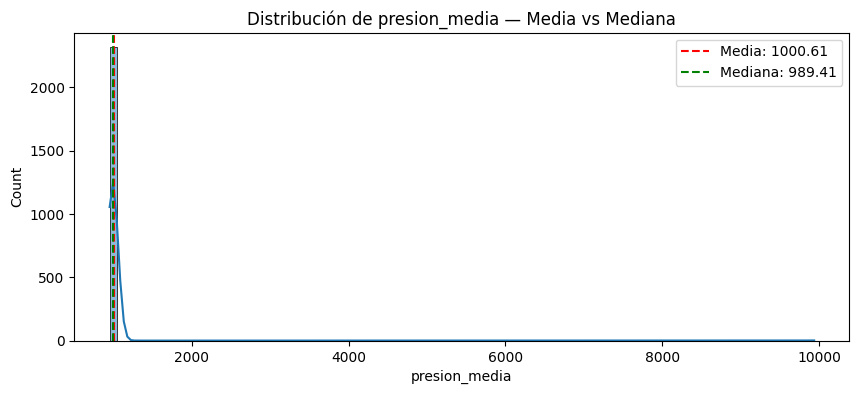

```python
# Comparación media vs mediana en una variable con nulos
col_ejemplo = 'presion_media'

media = data[col_ejemplo].mean()
mediana = data[col_ejemplo].median()

print(f"Media de {col_ejemplo}: {media:.4f}")
print(f"Mediana de {col_ejemplo}: {mediana:.4f}")
print(f"Diferencia: {abs(media - mediana):.4f}")

plt.figure(figsize=(10, 4))
sns.histplot(data[col_ejemplo].dropna(), kde=True)
plt.axvline(media, color='red', linestyle='--', label=f'Media: {media:.2f}')
plt.axvline(mediana, color='green', linestyle='--', label=f'Mediana: {mediana:.2f}')
plt.title(f'Distribución de {col_ejemplo} — Media vs Mediana')
plt.legend()
plt.show()
```

La imputación se realiza con `SimpleImputer` de scikit-learn, ajustado **únicamente sobre el conjunto de entrenamiento** dentro del pipeline — no sobre el dataset completo — para evitar fuga de datos (*data leakage*), tal como se explicó en la práctica de regresión lineal.

### Partición de los datos (train / test)

Siguiendo las indicaciones del laboratorio, dividimos el conjunto en 75% entrenamiento y 25% prueba, con semilla fija (`random_state=42`) para garantizar reproducibilidad. Esta división se hace **antes** de cualquier imputación o escalado, para que esas transformaciones se ajusten únicamente con los datos de entrenamiento y no haya fuga de información hacia el conjunto de prueba.

```python
target = 'temp_max_manana'

X = data.drop(columns=[target])
y = data[target]

X_train, X_test, y_train, y_test = train_test_split(X, y, test_size=0.25, random_state=42)

print(f"Train: {X_train.shape[0]} registros")
print(f"Test:  {X_test.shape[0]} registros")
```

```
Train: 1791 registros
Test:  598 registros
```

Tambien podemos ver a Y

```python
y_train.shape, y_test.shape
```

```
((1791,), (598,))
```

### Construcción de los dos pipelines de preparación y modelado

Se construyen dos pipelines que encapsulan todo el flujo de preparación + modelo, garantizando que la imputación y el escalado se ajusten solo con `X_train`. Ambos pipelines comparten la misma estructura general, pero difieren en dos decisiones justificadas en la sección anterior:

|  | Pipeline 1 | Pipeline 2 |
| --- | --- | --- |
| Imputación numéricas | Mediana | Media |
| Variable temporal | `mes` (categórica, one-hot) | `dia_del_anio` (numérica continua) |

En ambos se elimina `fecha` (no es predictora directa) y `estacion_anio` (redundante con `mes` y `dia_del_anio`, generaría colinealidad).

ATENCION: Para la creacion de este texto se uso IAG, pero fue para la generacion de la tabla ya que no sabiamos como crearla.

```python
# Columnas a eliminar en ambas estrategias (no predictoras directas / redundantes)
cols_a_eliminar = ['fecha', 'estacion_anio']

def drop_columns(df, cols=cols_a_eliminar):
    return df.drop(columns=cols, errors='ignore')

dropper = FunctionTransformer(drop_columns)
```

> **Nota sobre la elección de variables temporales**: se consideró usar `estacion_anio` en lugar de `mes` para el Pipeline 1, dado que ambas son categóricas y evitan forzar una relación lineal con el ciclo anual. Sin embargo, se mantiene `mes` porque ofrece mayor granularidad (12 categorías vs. 4) sin dejar de ser categórica, permitiendo que el modelo aprenda un efecto independiente por mes en lugar de agrupar meses completos en una sola estación.

### Escalado de variables numéricas

Como parte del preprocesamiento de cada pipeline, las variables numéricas se escalan con `StandardScaler` (dentro de `numeric_transformer_1`/`numeric_transformer_2`), llevándolas a media 0 y desviación estándar 1. Esto es necesario porque las variables del dataset tienen magnitudes muy distintas (ej. `presion_media` ronda los 990-1000, mientras que `viento_media` ronda un dígito) — sin escalar, el modelo de regresión lineal daría más peso a las variables de mayor magnitud simplemente por su escala, no por su relevancia real. El escalado se ajusta únicamente con los datos de entrenamiento (dentro del pipeline), evitando fuga de información hacia el conjunto de prueba.

```python
# PIPELINE 1: imputación por MEDIANA + variable temporal categórica (mes)

numeric_features_1 = [
    'presion_media', 'presion_min', 'presion_max', 'presion_desv',
    'humedad_media', 'humedad_min', 'humedad_max', 'humedad_desv',
    'viento_media', 'viento_min', 'viento_max', 'viento_desv',
    'rafaga_media', 'rafaga_min', 'rafaga_max', 'rafaga_desv',
    'viento_norte', 'viento_este', 'direccion_viento',
    'registros_del_dia', 'anio'
]
categorical_features_1 = ['mes', 'sector_viento']

numeric_transformer_1 = Pipeline(steps=[
    ('imputer', SimpleImputer(strategy='median')),
    ('scaler', StandardScaler()),
])
categorical_transformer_1 = Pipeline(steps=[
    ('imputer', SimpleImputer(strategy='most_frequent')),
    ('onehot', OneHotEncoder(handle_unknown='ignore')),
])

preprocessor_1 = ColumnTransformer(transformers=[
    ('num', numeric_transformer_1, numeric_features_1),
    ('cat', categorical_transformer_1, categorical_features_1),
])

pipeline_1 = Pipeline(steps=[
    ('dropper', dropper),
    ('preprocesamiento', preprocessor_1),
    ('modelo', LinearRegression())
])
```

```python
# PIPELINE 2: imputación por MEDIA + variable temporal numérica (dia_del_anio)

numeric_features_2 = numeric_features_1 + ['dia_del_anio']  # se agrega en vez de 'mes'
categorical_features_2 = ['sector_viento']  # ya no incluye mes

numeric_transformer_2 = Pipeline(steps=[
    ('imputer', SimpleImputer(strategy='mean')),
    ('scaler', StandardScaler()),
])
categorical_transformer_2 = Pipeline(steps=[
    ('imputer', SimpleImputer(strategy='most_frequent')),
    ('onehot', OneHotEncoder(handle_unknown='ignore')),
])

preprocessor_2 = ColumnTransformer(transformers=[
    ('num', numeric_transformer_2, numeric_features_2),
    ('cat', categorical_transformer_2, categorical_features_2),
])

pipeline_2 = Pipeline(steps=[
    ('dropper', dropper),
    ('preprocesamiento', preprocessor_2),
    ('modelo', LinearRegression())
])
```

### Entrenamiento

Entrenamos ambos pipelines completos (preparación + modelo) usando únicamente `X_train`, `y_train`. Scikit-learn se encarga de que cada paso (imputación, escalado, codificación) se ajuste solo con estos datos y luego se aplique consistentemente sobre `X_test` cuando se use `.predict()`.

```python
pipeline_1.fit(X_train, y_train)
print("Pipeline 1 (mediana + mes) entrenado correctamente.")
```

```
Pipeline 1 (mediana + mes) entrenado correctamente.
```

```python
pipeline_2.fit(X_train, y_train)
print("Pipeline 2 (media + dia_del_anio) entrenado correctamente.")
```

```
Pipeline 2 (media + dia_del_anio) entrenado correctamente.
```

Ahora veamos de forma rapida como se ven los pipelines

```python
from sklearn import set_config
set_config(display='diagram')
```

```python
pipeline_1
```

```
Pipeline(steps=[('dropper',
                 FunctionTransformer(func=<function drop_columns at 0x000001D60757A700>)),
                ('preprocesamiento',
                 ColumnTransformer(transformers=[('num',
                                                  Pipeline(steps=[('imputer',
                                                                   SimpleImputer(strategy='median')),
                                                                  ('scaler',
                                                                   StandardScaler())]),
                                                  ['presion_media',
                                                   'presion_min', 'presion_max',
                                                   'presion_desv',
                                                   'humedad_media',
                                                   'humedad_min', 'humedad_max'...
                                                   'viento_media', 'viento_min',
                                                   'viento_max', 'viento_desv',
                                                   'rafaga_media', 'rafaga_min',
                                                   'rafaga_max', 'rafaga_desv',
                                                   'viento_norte',
                                                   'viento_este',
                                                   'direccion_viento',
                                                   'registros_del_dia',
                                                   'anio']),
                                                 ('cat',
                                                  Pipeline(steps=[('imputer',
                                                                   SimpleImputer(strategy='most_frequent')),
                                                                  ('onehot',
                                                                   OneHotEncoder(handle_unknown='ignore'))]),
                                                  ['mes', 'sector_viento'])])),
                ('modelo', LinearRegression())])
```

```python
pipeline_2
```

```
Pipeline(steps=[('dropper',
                 FunctionTransformer(func=<function drop_columns at 0x000001D60757A700>)),
                ('preprocesamiento',
                 ColumnTransformer(transformers=[('num',
                                                  Pipeline(steps=[('imputer',
                                                                   SimpleImputer()),
                                                                  ('scaler',
                                                                   StandardScaler())]),
                                                  ['presion_media',
                                                   'presion_min', 'presion_max',
                                                   'presion_desv',
                                                   'humedad_media',
                                                   'humedad_min', 'humedad_max',
                                                   'humedad_desv',
                                                   '...
                                                   'viento_max', 'viento_desv',
                                                   'rafaga_media', 'rafaga_min',
                                                   'rafaga_max', 'rafaga_desv',
                                                   'viento_norte',
                                                   'viento_este',
                                                   'direccion_viento',
                                                   'registros_del_dia', 'anio',
                                                   'dia_del_anio']),
                                                 ('cat',
                                                  Pipeline(steps=[('imputer',
                                                                   SimpleImputer(strategy='most_frequent')),
                                                                  ('onehot',
                                                                   OneHotEncoder(handle_unknown='ignore'))]),
                                                  ['sector_viento'])])),
                ('modelo', LinearRegression())])
```

### Estructura de los pipelines

Los diagramas anteriores confirman que ambos pipelines siguen la misma estructura general (eliminación de columnas → preprocesamiento por tipo de variable → modelo), pero difieren exactamente en los dos puntos que planteamos:

- **Pipeline 1**: 21 variables numéricas (imputadas con mediana) + 2 variables categóricas, `mes` y `sector_viento` (imputadas por moda y codificadas con One-Hot, generando 20 columnas binarias). En total, el modelo recibe 41 variables de entrada.
- **Pipeline 2**: 22 variables numéricas (imputadas con media) — una más que el Pipeline 1, porque aquí `dia_del_anio` se trata como numérica en lugar de categórica — y solo 1 variable categórica, `sector_viento` (8 columnas binarias). En total, el modelo recibe 30 variables de entrada.

### Predicciones y métricas de evaluación (train / test)

Con los dos pipelines ya entrenados, generamos las predicciones sobre `X_train` y `X_test` para cada uno y calculamos las métricas de calidad pertinentes para un problema de regresión: **MSE**, **RMSE**, **MAE** y **R²**. Calculamos las métricas tanto en train como en test para poder detectar sobreajuste (una diferencia grande entre ambas indicaría que el modelo memoriza el train en vez de generalizar).

```python
def evaluar_pipeline(pipeline, X, y):
    """Genera predicciones y calcula MSE, RMSE, MAE y R2 para un pipeline ya entrenado."""
    y_pred = pipeline.predict(X)
    mse = mean_squared_error(y, y_pred)
    rmse = np.sqrt(mse)
    mae = mean_absolute_error(y, y_pred)
    r2 = r2_score(y, y_pred)
    return y_pred, mse, rmse, mae, r2

# Pipeline 1: mediana + mes categorico
y_train_pred_1, mse_train_1, rmse_train_1, mae_train_1, r2_train_1 = evaluar_pipeline(pipeline_1, X_train, y_train)
y_test_pred_1, mse_test_1, rmse_test_1, mae_test_1, r2_test_1 = evaluar_pipeline(pipeline_1, X_test, y_test)

# Pipeline 2: media + dia_del_anio numerico
y_train_pred_2, mse_train_2, rmse_train_2, mae_train_2, r2_train_2 = evaluar_pipeline(pipeline_2, X_train, y_train)
y_test_pred_2, mse_test_2, rmse_test_2, mae_test_2, r2_test_2 = evaluar_pipeline(pipeline_2, X_test, y_test)

tabla_metricas = pd.DataFrame({
    'Modelo': ['Pipeline 1 (mediana + mes)', 'Pipeline 1 (mediana + mes)',
               'Pipeline 2 (media + dia_del_anio)', 'Pipeline 2 (media + dia_del_anio)'],
    'Conjunto': ['Train', 'Test', 'Train', 'Test'],
    'MSE': [mse_train_1, mse_test_1, mse_train_2, mse_test_2],
    'RMSE': [rmse_train_1, rmse_test_1, rmse_train_2, rmse_test_2],
    'MAE': [mae_train_1, mae_test_1, mae_train_2, mae_test_2],
    'R2': [r2_train_1, r2_test_1, r2_train_2, r2_test_2],
})

tabla_metricas
```

|  | Modelo | Conjunto | MSE | RMSE | MAE | R2 |
| --- | --- | --- | --- | --- | --- | --- |
| 0 | Pipeline 1 (mediana + mes) | Train | 45.426915 | 6.739949 | 5.185540 | 0.466738 |
| 1 | Pipeline 1 (mediana + mes) | Test | 41.193999 | 6.418255 | 5.049237 | 0.475793 |
| 2 | Pipeline 2 (media + dia_del_anio) | Train | 46.479608 | 6.817595 | 5.291983 | 0.454380 |
| 3 | Pipeline 2 (media + dia_del_anio) | Test | 40.803506 | 6.387762 | 5.028849 | 0.480762 |

#### Tabla comparativa sobre el conjunto de prueba

Aislamos las filas de `Test` de la tabla anterior para tener, de forma explícita, la comparación de desempeño de los dos mejores modelos analizados sobre datos que el modelo no vio durante el entrenamiento — que es lo que realmente importa para decidir cuál usar en producción.

```python
tabla_comparativa_test = (
    tabla_metricas[tabla_metricas['Conjunto'] == 'Test']
    .drop(columns='Conjunto')
    .set_index('Modelo')
    .round(3)
)
tabla_comparativa_test
```

| Modelo | MSE | RMSE | MAE | R2 |
| --- | --- | --- | --- | --- |
| Pipeline 1 (mediana + mes) | 41.194 | 6.418 | 5.049 | 0.476 |
| Pipeline 2 (media + dia_del_anio) | 40.804 | 6.388 | 5.029 | 0.481 |

Comparando el **RMSE, MAE y R² sobre el conjunto de prueba** —que es lo relevante para elegir un modelo, ya que el desempeño en train no garantiza generalización— el **Pipeline 2** (imputación por media + `dia_del_anio` numérico) tiene un desempeño ligeramente mejor que el Pipeline 1: un RMSE de 6.388°C frente a 6.418°C, un MAE de 5.029°C frente a 5.049°C, y un R² de 0.481 frente a 0.476. Es decir, en promedio el Pipeline 2 se equivoca casi 0.03°C menos por día y explica cerca de medio punto porcentual más de la variabilidad de la temperatura máxima del día siguiente. La diferencia es pequeña, pero consistente en las tres métricas a favor del mismo modelo, y además el Pipeline 2 logra este resultado con menos variables de entrada (30 vs. 41 tras la codificación categórica), lo que lo hace un modelo más simple y con menor riesgo de sobreajustar en datos futuros. Por eso lo elegimos como el modelo base para las siguientes etapas de este laboratorio (verificación de supuestos e interpretación de coeficientes).

En cuanto a qué tan bueno es este desempeño **en el contexto del problema planteado por AlpesPlanck**: un R² de ~0.48 significa que las variables meteorológicas del mismo día explican apenas la mitad de la variabilidad de la temperatura máxima del día siguiente — el resto depende de factores que no están en este dataset (por ejemplo, el estado del tiempo en días previos o en estaciones vecinas). En términos prácticos, un MAE de ~5°C es un margen de error importante si el objetivo es anticipar picos de temperatura asociados a riesgo de incendios forestales o a fenómenos como El Niño/La Niña: el modelo puede servir como una primera señal de alerta o como insumo para un sistema más completo, pero por sí solo no ofrece la precisión suficiente para decisiones críticas sin acompañarlo de otras fuentes de información (por ejemplo, series de tiempo de días anteriores, que el modelo actual no usa explícitamente).

También vemos que en ambos pipelines las métricas de test son iguales o incluso un poco mejores que las de train (el RMSE de test es menor que el de train en los dos casos). Esto es una buena señal: descarta que haya sobreajuste, es decir, el modelo no está memorizando el conjunto de entrenamiento sino generalizando de forma consistente a datos que no ha visto.

ATENCION: Para la generación del código de esta sección (la función `evaluar_pipeline`, la construcción de la tabla comparativa y su versión filtrada por test) se usó apoyo de IAG, ya que conocíamos la lógica del cálculo de métricas por el patrón visto en la práctica P4.1 pero queríamos automatizarla para los dos pipelines al tiempo. La interpretación de los resultados (el análisis de sobreajuste, la comparación entre pipelines y su relación con el problema de AlpesPlanck) la hicimos y verificamos nosotros contrastando directamente los valores numéricos obtenidos en la tabla.

## Verificación de supuestos de la regresión lineal

Antes de interpretar los coeficientes, siguiendo el patrón visto en la práctica **P4.2 (Verificación de supuestos)**, validamos los supuestos clásicos de la regresión lineal: no colinealidad, normalidad de los errores, homocedasticidad, independencia de los errores y linealidad. Si estos supuestos no se cumplen, los coeficientes pueden no ser confiables para interpretar el fenómeno, aunque el modelo siga prediciendo razonablemente bien.

Con base en la tabla de métricas de la sección anterior, tomamos el **Pipeline 2** (imputación por media + `dia_del_anio` numérico) como el modelo sobre el cual hacemos esta verificación y, si los resultados lo respaldan, la interpretación de coeficientes: tuvo un desempeño levemente mejor en test y usa menos variables de entrada (30 vs. 41), lo que también facilita la interpretación.

```python
# Obtenemos el dataset de entrenamiento ya transformado por el pipeline (sin el paso del
# modelo), necesario para las pruebas estadisticas de los supuestos (mismo enfoque que P4.2)
dropper_step = pipeline_2.named_steps['dropper']
preprocesamiento_2 = pipeline_2.named_steps['preprocesamiento']

X_train_dropped_2 = dropper_step.transform(X_train)
Xt_train_2 = preprocesamiento_2.transform(X_train_dropped_2)

feature_names_2 = preprocesamiento_2.get_feature_names_out()
feature_names_2 = [n.replace('num__', '').replace('cat__', '') for n in feature_names_2]

import scipy.sparse
if scipy.sparse.issparse(Xt_train_2):
    Xt_train_2 = Xt_train_2.toarray()

Xt_train_2_df = pd.DataFrame(Xt_train_2, columns=feature_names_2, index=X_train.index)

residuales_2 = np.array(y_train - y_train_pred_2)

print(f"Dataset transformado: {Xt_train_2_df.shape[0]} filas x {Xt_train_2_df.shape[1]} columnas")
```

```
Dataset transformado: 1791 filas x 30 columnas
```

### Multicolinealidad (VIF)

Calculamos el Factor de Inflación de Varianza (VIF) para cada variable numérica del modelo transformado. Un VIF alto (convencionalmente > 5, y crítico si > 10) indica que esa variable está muy correlacionada con una combinación lineal de las otras, lo que hace inestables sus coeficientes.

```python
X_vif_2 = Xt_train_2_df.select_dtypes(include="number").copy()

vif_values_2 = []
with np.errstate(divide="ignore", invalid="ignore"):
    for i in range(X_vif_2.shape[1]):
        vif = variance_inflation_factor(X_vif_2.values, i)
        vif_values_2.append(vif)

vif_data_2 = pd.DataFrame({
    "Variable": X_vif_2.columns,
    "VIF": vif_values_2
}).sort_values("VIF", ascending=False)

vif_data_2
```

|  | Variable | VIF |
| --- | --- | --- |
| 11 | viento_desv | 19.708685 |
| 15 | rafaga_desv | 19.620427 |
| 1 | presion_min | 13.191638 |
| 2 | presion_max | 10.536249 |
| 4 | humedad_media | 7.583484 |
| 8 | viento_media | 7.537383 |
| 5 | humedad_min | 7.359796 |
| 7 | humedad_desv | 6.003616 |
| 17 | viento_este | 5.553810 |
| 18 | direccion_viento | 5.078243 |
| 10 | viento_max | 4.995817 |
| 16 | viento_norte | 4.941961 |
| 12 | rafaga_media | 4.831808 |
| 24 | sector_viento_NE | 4.467024 |
| 6 | humedad_max | 3.466181 |
| 3 | presion_desv | 3.130524 |
| 14 | rafaga_max | 2.659320 |
| 9 | viento_min | 2.547937 |
| 26 | sector_viento_O | 2.416998 |
| 13 | rafaga_min | 2.140071 |
| 29 | sector_viento_SO | 2.104529 |
| 27 | sector_viento_S | 1.733845 |
| 23 | sector_viento_N | 1.426337 |
| 25 | sector_viento_NO | 1.349473 |
| 22 | sector_viento_E | 1.290609 |
| 28 | sector_viento_SE | 1.144581 |
| 21 | dia_del_anio | 1.074897 |
| 0 | presion_media | 1.031834 |
| 20 | anio | 1.026806 |
| 19 | registros_del_dia | 1.010409 |

### Normalidad de los errores (Shapiro-Wilk + histograma + Q-Q plot)

```
Shapiro-Wilk estadistico: 0.9749405209221577
Shapiro-Wilk p-value   : 3.76310585703779e-17
```

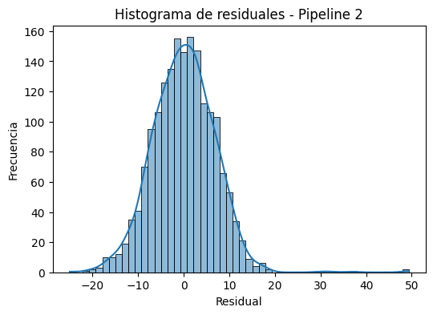

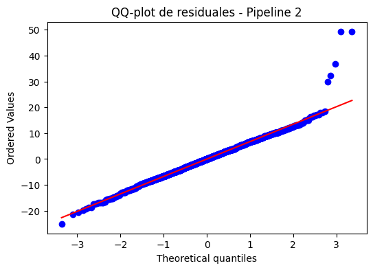

```python
estat_shapiro_2, p_shapiro_2 = shapiro(residuales_2)
print("Shapiro-Wilk estadistico:", estat_shapiro_2)
print("Shapiro-Wilk p-value   :", p_shapiro_2)

plt.figure(figsize=(6, 4))
sns.histplot(residuales_2, kde=True)
plt.title("Histograma de residuales - Pipeline 2")
plt.xlabel("Residual")
plt.ylabel("Frecuencia")
plt.show()

plt.figure(figsize=(6, 4))
stats.probplot(residuales_2, dist="norm", plot=plt)
plt.title("QQ-plot de residuales - Pipeline 2")
plt.show()
```

### Homocedasticidad (Breusch-Pagan)

```python
X_num_2 = Xt_train_2_df.select_dtypes(include="number").copy()
mask_2 = np.isfinite(X_num_2).all(axis=1)
X_num_2_clean = X_num_2[mask_2]
resid_2_clean = residuales_2[mask_2]
X_num_2_const = sm.add_constant(X_num_2_clean)

bp_stat_2, bp_pvalue_2, _, _ = het_breuschpagan(resid_2_clean, X_num_2_const)

print("Estadistico Breusch-Pagan:", bp_stat_2)
print("p-value Breusch-Pagan   :", bp_pvalue_2)
```

```
Estadistico Breusch-Pagan: 91.4738935899367
p-value Breusch-Pagan   : 3.91925976342267e-08
```

### Independencia de los errores (Durbin-Watson)

```python
dw_2 = durbin_watson(residuales_2)
print("Durbin-Watson:", dw_2)
```

```
Durbin-Watson: 2.066247415151876
```

### Linealidad (Rainbow test)

```python
X_sm_2 = sm.add_constant(Xt_train_2_df)
modelo_sm_2 = sm.OLS(y_train, X_sm_2).fit()

rainbow_stat_2, rainbow_pvalue_2 = linear_rainbow(modelo_sm_2)

print("Estadistico Rainbow:", rainbow_stat_2)
print("p-value Rainbow    :", rainbow_pvalue_2)
```

```
Estadistico Rainbow: 1.0139701566270238
p-value Rainbow    : 0.41865318433542026
```

### Diagnóstico visual complementario

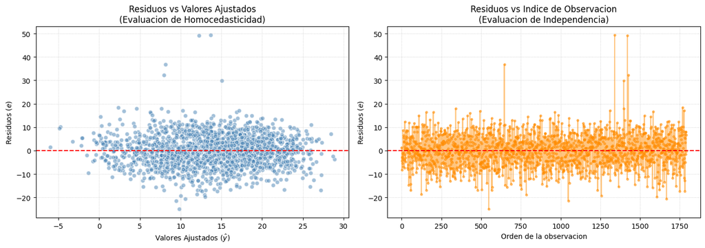

```python
# Reutilizamos el modelo OLS ya ajustado (con constante) para obtener valores ajustados y
# residuos, y verificar visualmente homocedasticidad e independencia
fitted_values_2 = modelo_sm_2.fittedvalues
residuals_plot_2 = modelo_sm_2.resid

plt.figure(figsize=(14, 5))

plt.subplot(1, 2, 1)
plt.scatter(fitted_values_2, residuals_plot_2, alpha=0.5, color='steelblue', edgecolors='white')
plt.axhline(y=0, color='red', linestyle='--')
plt.title('Residuos vs Valores Ajustados\n(Evaluacion de Homocedasticidad)')
plt.xlabel(r'Valores Ajustados ($\hat{y}$)')
plt.ylabel('Residuos ($e$)')
plt.grid(True, linestyle=':', alpha=0.6)

plt.subplot(1, 2, 2)
plt.plot(range(len(residuals_plot_2)), residuals_plot_2, marker='o', linestyle='-',
         markersize=3, alpha=0.5, color='darkorange')
plt.axhline(y=0, color='red', linestyle='--')
plt.title('Residuos vs Indice de Observacion\n(Evaluacion de Independencia)')
plt.xlabel('Orden de la observacion')
plt.ylabel('Residuos ($e$)')
plt.grid(True, linestyle=':', alpha=0.6)

plt.tight_layout()
plt.show()
```

### Resumen de supuestos

```python
cumple_colinealidad = vif_data_2['VIF'].max() < 5
cumple_normalidad = p_shapiro_2 > 0.05
cumple_homoced = bp_pvalue_2 > 0.05
cumple_independencia = 1.5 < dw_2 < 2.5
cumple_linealidad = rainbow_pvalue_2 > 0.05

resumen_supuestos_2 = pd.DataFrame({
    'Supuesto': ['No colinealidad', 'Normalidad de errores', 'Homocedasticidad',
                 'Independencia de errores', 'Linealidad'],
    'Prueba': ['VIF', 'Shapiro-Wilk', 'Breusch-Pagan', 'Durbin-Watson', 'Rainbow'],
    'Resultado': [f"VIF max = {vif_data_2['VIF'].max():.2f}", f"p = {p_shapiro_2:.2e}",
                  f"p = {bp_pvalue_2:.4f}", f"DW = {dw_2:.3f}", f"p = {rainbow_pvalue_2:.3f}"],
    'Se cumple': ['Si' if c else 'No' for c in [cumple_colinealidad, cumple_normalidad,
                                                  cumple_homoced, cumple_independencia,
                                                  cumple_linealidad]]
})
resumen_supuestos_2
```

|  | Supuesto | Prueba | Resultado | Se cumple |
| --- | --- | --- | --- | --- |
| 0 | No colinealidad | VIF | VIF max = 19.71 | No |
| 1 | Normalidad de errores | Shapiro-Wilk | p = 3.76e-17 | No |
| 2 | Homocedasticidad | Breusch-Pagan | p = 0.0000 | No |
| 3 | Independencia de errores | Durbin-Watson | DW = 2.066 | Si |
| 4 | Linealidad | Rainbow | p = 0.419 | Si |

Con los resultados anteriores, el modelo cumple 2 de los 5 supuestos clásicos y falla en 3:

- **Multicolinealidad**: no se cumple. El VIF máximo es 19.71 (`viento_desv`), seguido de cerca por `rafaga_desv` (19.62), `presion_min` (13.19) y `presion_max` (10.54), todos por encima del umbral crítico de 10. Esto tiene sentido físico: dentro de un mismo día, la mínima, máxima, media y desviación de una misma variable meteorológica (presión, humedad, viento, ráfaga) están naturalmente correlacionadas entre sí, y además `viento_norte`, `viento_este` y `direccion_viento` codifican en parte la misma información (la dirección del viento descompuesta en componentes vectoriales). Esto no invalida las predicciones del modelo, pero sí significa que no podemos confiar del todo en la magnitud individual de los coeficientes de estas variables correlacionadas al momento de interpretar cuál "importa más" — algo que tendremos en cuenta en la siguiente etapa.
- **Normalidad de los errores**: no se cumple según Shapiro-Wilk (p = 3.76e-17). Sin embargo, con un tamaño de muestra tan grande (1791 observaciones), esta prueba es extremadamente sensible a desviaciones mínimas de la normalidad perfecta. Por eso conviene revisar también el histograma y el Q-Q plot: si la forma es aproximadamente simétrica y solo se desvía en las colas, el impacto práctico sobre las predicciones sigue siendo limitado (aunque sí compromete la validez formal de los intervalos de confianza y las pruebas de significancia sobre los coeficientes).
- **Homocedasticidad**: no se cumple según Breusch-Pagan (p = 3.92e-8). Hay heterocedasticidad, es decir, la varianza de los errores no es constante para todos los niveles de la predicción. Esto no sesga los coeficientes, pero sí implica que sus errores estándar (y por tanto los intervalos de confianza y p-values asociados) no son del todo confiables.
- **Independencia de los errores**: se cumple según Durbin-Watson (DW = 2.066, muy cercano al valor ideal de 2). Vale la pena una salvedad importante: `train_test_split` mezcla aleatoriamente el orden cronológico original de los registros, por lo cual este resultado solo confirma que no hay dependencia en el orden en que quedaron los datos después de la partición — no descarta que exista autocorrelación temporal real entre días consecutivos (por ejemplo, que la temperatura de un día esté relacionada con la del día anterior), que es justamente el tipo de estructura que este pipeline no está capturando explícitamente.
- **Linealidad**: se cumple según el Rainbow test (p = 0.419). No hay evidencia de que la relación entre las variables predictoras y la temperatura máxima del día siguiente se aleje de una forma lineal.

En conjunto, el modelo predice de forma razonable (como vimos en la sección de métricas) y su relación con las variables es efectivamente lineal e independiente en el orden de los datos, pero la interpretación de los coeficientes individuales debe hacerse con cautela: la multicolinealidad entre variables meteorológicas correlacionadas y la heterocedasticidad de los errores significan que no todos los coeficientes son igual de confiables para "explicar" el fenómeno, aunque sí sirvan en conjunto para predecir.

ATENCION: Para el código de esta sección usamos como base el patrón visto en la práctica P4.2 (Verificación de supuestos), adaptándolo a nuestras variables y al Pipeline 2 (los nombres de columnas, el paso de extraer el dataset transformado, y la reutilización del modelo OLS ya ajustado para las gráficas de diagnóstico en vez de reajustarlo con `ols()` como en la práctica). También usamos apoyo puntual de IAG para recordar la sintaxis correcta de `variance_inflation_factor` sobre un DataFrame y de `het_breuschpagan`. La interpretación de cada resultado (por qué falla la multicolinealidad dado el contexto físico de las variables, la salvedad sobre el orden cronológico en Durbin-Watson, y la relación entre heterocedasticidad/normalidad y la confiabilidad de los coeficientes) la hicimos nosotros, contrastando los p-values obtenidos contra el umbral convencional de 0.05 y los conceptos vistos en clase.

## Interpretación de coeficientes e importancia de variables

Extraemos el intercepto y los coeficientes del modelo de regresión lineal dentro del **Pipeline 2**, siguiendo el mismo patrón de la práctica P4.2. Como las variables numéricas fueron escaladas con `StandardScaler`, los coeficientes sí son comparables entre sí en magnitud (todos están en la misma escala de "desviaciones estándar"), lo que nos permite hablar de variables con mayor o menor peso en la predicción.

- No podemos hacer pruebas de significancia formales (t-test, p-values, intervalos de confianza) sobre los coeficientes individuales, porque esas pruebas asumen errores normales y homocedásticos — algo que aquí no se cumple.
- Los coeficientes de variables con VIF alto no se pueden interpretar de forma aislada, porque el modelo no puede distinguir con confianza cuánto del efecto le corresponde a cada una por separado (a diferencia del ejercicio de P4.2, aquí ningún VIF salió infinito — no hay colinealidad *perfecta* que obligue a eliminar variables — pero sí hay varias por encima de los umbrales de alerta de 5 y 10, así que las tratamos con el mismo cuidado en la interpretación, sin necesidad de descartarlas del modelo).

```python
Modelo_2 = pipeline_2.named_steps['modelo']

print("Intercepto:", Modelo_2.intercept_)

coef_df_2 = pd.DataFrame({
    "Variable": feature_names_2,
    "Coeficiente": Modelo_2.coef_
})
coef_df_2.sort_values('Coeficiente', ascending=False)
```

```
Intercepto: 14.142425746130627
```

|  | Variable | Coeficiente |
| --- | --- | --- |
| 7 | humedad_desv | 3.343583 |
| 21 | dia_del_anio | 2.035818 |
| 11 | viento_desv | 1.045240 |
| 22 | sector_viento_E | 0.969074 |
| 24 | sector_viento_NE | 0.705218 |
| 20 | anio | 0.702485 |
| 14 | rafaga_max | 0.568896 |
| 23 | sector_viento_N | 0.525674 |
| 8 | viento_media | 0.448395 |
| 10 | viento_max | 0.128824 |
| 28 | sector_viento_SE | 0.079275 |
| 29 | sector_viento_SO | 0.029673 |
| 26 | sector_viento_O | 0.011236 |
| 0 | presion_media | -0.021769 |
| 19 | registros_del_dia | -0.081899 |
| 5 | humedad_min | -0.090117 |
| 1 | presion_min | -0.129235 |
| 2 | presion_max | -0.148308 |
| 13 | rafaga_min | -0.270775 |
| 6 | humedad_max | -0.279484 |
| 16 | viento_norte | -0.338549 |
| 18 | direccion_viento | -0.346488 |
| 9 | viento_min | -0.384103 |
| 17 | viento_este | -0.631227 |
| 25 | sector_viento_NO | -0.766771 |
| 15 | rafaga_desv | -0.835493 |
| 12 | rafaga_media | -1.310228 |
| 3 | presion_desv | -1.365859 |
| 27 | sector_viento_S | -1.553379 |
| 4 | humedad_media | -2.461377 |

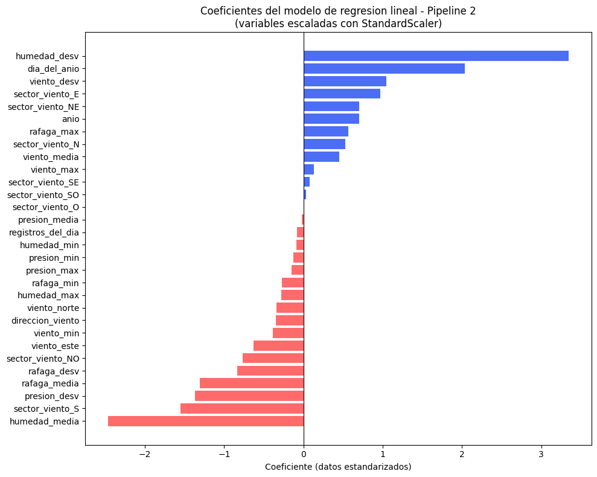

```
Azul = efecto positivo en la temperatura maxima del dia siguiente | Rojo = efecto negativo
Los coeficientes son comparables entre si porque las variables estan estandarizadas.
```

```python
# Visualizacion de coeficientes ordenados (mismo estilo que P4.2)
coef_sorted_2 = coef_df_2.sort_values('Coeficiente')
colors_2 = ['#FF6B6B' if c < 0 else '#4C6EF5' for c in coef_sorted_2['Coeficiente']]

plt.figure(figsize=(10, 8))
plt.barh(coef_sorted_2['Variable'], coef_sorted_2['Coeficiente'], color=colors_2)
plt.axvline(0, color='black', linewidth=0.8)
plt.xlabel('Coeficiente (datos estandarizados)')
plt.title('Coeficientes del modelo de regresion lineal - Pipeline 2\n(variables escaladas con StandardScaler)')
plt.tight_layout()
plt.show()
print("Azul = efecto positivo en la temperatura maxima del dia siguiente | Rojo = efecto negativo")
print("Los coeficientes son comparables entre si porque las variables estan estandarizadas.")
```

### Tabla de importancia de variables (coeficiente + VIF)

Para no caer en el error de interpretar un coeficiente grande como "variable importante" sin más, cruzamos la magnitud de cada coeficiente con su VIF (calculado en la sección anterior) y asignamos una etiqueta de confiabilidad:

- **Confiable (VIF < 5)**: no hay evidencia relevante de multicolinealidad, el coeficiente se puede interpretar de forma razonablemente directa.
- **Interpretar con cautela (VIF entre 5 y 10)**: hay colinealidad moderada; la dirección (signo) del efecto suele seguir siendo informativa, pero no su magnitud exacta.
- **No confiable individualmente (VIF > 10)**: alta colinealidad; el coeficiente puede estar "repartiendo" artificialmente el efecto con otra(s) variable(s) correlacionada(s). Si el VIF hubiera salido infinito (colinealidad perfecta, como en el ejercicio de P4.2), ni siquiera tendría sentido mirar el coeficiente individual — aquí no llegamos a ese extremo, pero tratamos estos casos con el mismo nivel de desconfianza en la interpretación uno por uno.

```python
def confiabilidad(vif):
    if pd.isna(vif) or not np.isfinite(vif):
        return 'No confiable (colinealidad perfecta)'
    elif vif > 10:
        return 'No confiable individualmente (VIF > 10)'
    elif vif > 5:
        return 'Interpretar con cautela (VIF 5-10)'
    else:
        return 'Confiable (VIF < 5)'

tabla_importancia = coef_df_2.merge(vif_data_2, on='Variable', how='left')
tabla_importancia['Importancia_abs'] = tabla_importancia['Coeficiente'].abs()
tabla_importancia['Confiabilidad_individual'] = tabla_importancia['VIF'].apply(confiabilidad)
tabla_importancia = tabla_importancia.sort_values('Importancia_abs', ascending=False)
tabla_importancia = tabla_importancia[['Variable', 'Coeficiente', 'Importancia_abs', 'VIF',
                                        'Confiabilidad_individual']].reset_index(drop=True)
tabla_importancia
```

|  | Variable | Coeficiente | Importancia_abs | VIF | Confiabilidad_individual |
| --- | --- | --- | --- | --- | --- |
| 0 | humedad_desv | 3.343583 | 3.343583 | 6.003616 | Interpretar con cautela (VIF 5-10) |
| 1 | humedad_media | -2.461377 | 2.461377 | 7.583484 | Interpretar con cautela (VIF 5-10) |
| 2 | dia_del_anio | 2.035818 | 2.035818 | 1.074897 | Confiable (VIF < 5) |
| 3 | sector_viento_S | -1.553379 | 1.553379 | 1.733845 | Confiable (VIF < 5) |
| 4 | presion_desv | -1.365859 | 1.365859 | 3.130524 | Confiable (VIF < 5) |
| 5 | rafaga_media | -1.310228 | 1.310228 | 4.831808 | Confiable (VIF < 5) |
| 6 | viento_desv | 1.045240 | 1.045240 | 19.708685 | No confiable individualmente (VIF > 10) |
| 7 | sector_viento_E | 0.969074 | 0.969074 | 1.290609 | Confiable (VIF < 5) |
| 8 | rafaga_desv | -0.835493 | 0.835493 | 19.620427 | No confiable individualmente (VIF > 10) |
| 9 | sector_viento_NO | -0.766771 | 0.766771 | 1.349473 | Confiable (VIF < 5) |
| 10 | sector_viento_NE | 0.705218 | 0.705218 | 4.467024 | Confiable (VIF < 5) |
| 11 | anio | 0.702485 | 0.702485 | 1.026806 | Confiable (VIF < 5) |
| 12 | viento_este | -0.631227 | 0.631227 | 5.553810 | Interpretar con cautela (VIF 5-10) |
| 13 | rafaga_max | 0.568896 | 0.568896 | 2.659320 | Confiable (VIF < 5) |
| 14 | sector_viento_N | 0.525674 | 0.525674 | 1.426337 | Confiable (VIF < 5) |
| 15 | viento_media | 0.448395 | 0.448395 | 7.537383 | Interpretar con cautela (VIF 5-10) |
| 16 | viento_min | -0.384103 | 0.384103 | 2.547937 | Confiable (VIF < 5) |
| 17 | direccion_viento | -0.346488 | 0.346488 | 5.078243 | Interpretar con cautela (VIF 5-10) |
| 18 | viento_norte | -0.338549 | 0.338549 | 4.941961 | Confiable (VIF < 5) |
| 19 | humedad_max | -0.279484 | 0.279484 | 3.466181 | Confiable (VIF < 5) |
| 20 | rafaga_min | -0.270775 | 0.270775 | 2.140071 | Confiable (VIF < 5) |
| 21 | presion_max | -0.148308 | 0.148308 | 10.536249 | No confiable individualmente (VIF > 10) |
| 22 | presion_min | -0.129235 | 0.129235 | 13.191638 | No confiable individualmente (VIF > 10) |
| 23 | viento_max | 0.128824 | 0.128824 | 4.995817 | Confiable (VIF < 5) |
| 24 | humedad_min | -0.090117 | 0.090117 | 7.359796 | Interpretar con cautela (VIF 5-10) |
| 25 | registros_del_dia | -0.081899 | 0.081899 | 1.010409 | Confiable (VIF < 5) |
| 26 | sector_viento_SE | 0.079275 | 0.079275 | 1.144581 | Confiable (VIF < 5) |
| 27 | sector_viento_SO | 0.029673 | 0.029673 | 2.104529 | Confiable (VIF < 5) |
| 28 | presion_media | -0.021769 | 0.021769 | 1.031834 | Confiable (VIF < 5) |
| 29 | sector_viento_O | 0.011236 | 0.011236 | 2.416998 | Confiable (VIF < 5) |

### Verificación cruzada con relaciones simples en los datos

Antes de escribir la interpretación, contrastamos el signo de los coeficientes de las variables "confiables" (VIF bajo) con su relación simple (no condicionada a las demás variables) con el target, usando el DataFrame ya limpio. Esto nos permite detectar si un coeficiente parece razonable o si su lectura es más compleja de lo que sugiere el número.

```python
print("Correlacion simple presion_desv vs temp_max_manana:",
      round(data[['presion_desv', 'temp_max_manana']].corr().iloc[0, 1], 3))
print("Correlacion simple rafaga_media vs temp_max_manana:",
      round(data[['rafaga_media', 'temp_max_manana']].corr().iloc[0, 1], 3))
print("Correlacion simple dia_del_anio vs temp_max_manana:",
      round(data[['dia_del_anio', 'temp_max_manana']].corr().iloc[0, 1], 3))
print()
print("Temperatura maxima promedio del dia siguiente, por sector de viento:")
print(data.groupby('sector_viento')['temp_max_manana'].mean().sort_values().round(2))
```

```
Correlacion simple presion_desv vs temp_max_manana: -0.204
Correlacion simple rafaga_media vs temp_max_manana: -0.12
Correlacion simple dia_del_anio vs temp_max_manana: 0.166

Temperatura maxima promedio del dia siguiente, por sector de viento:
sector_viento
N     11.85
NO    12.98
S     13.09
NE    13.17
O     13.19
SO    14.38
SE    17.84
E     19.51
Name: temp_max_manana, dtype: float64
```

### Interpretación — apoyada en las pruebas del paso anterior y en los datos crudos

Antes de decir cuáles variables "importan más", separamos los coeficientes grandes que **sí** podemos interpretar de los que **no**, usando la columna `Confiabilidad_individual` de la tabla anterior, y los contrastamos con la verificación cruzada de arriba.

**Coeficientes con VIF bajo, pero que igual hay que leer con matices:**

- `dia_del_anio` (+2.04, VIF = 1.07): es el coeficiente más grande entre los de VIF bajo, pero su lectura directa ("a mayor día del año, mayor temperatura") sería engañosa. Su correlación simple con la temperatura es de apenas 0.166, muy por debajo de lo que sugeriría un coeficiente estandarizado de 2.04 — esto es consistente con que la relación real entre día del año y temperatura tiene forma de joroba (fría a inicio y fin de año, cálida a mitad de año), no una tendencia lineal creciente. El coeficiente positivo es apenas una aproximación lineal parcial de ese ciclo, y buena parte de su peso en el modelo probablemente proviene de su combinación con otras variables correlacionadas con la época del año (presión, humedad). Esto confirma, con datos, el trade-off que ya había anotado nuestro compañero al justificar la elección entre `mes` (categórica, sin asumir linealidad) y `dia_del_anio` (numérica, asumiendo un efecto lineal): el supuesto de linealidad para el ciclo anual es débil, y el Pipeline 1 (con `mes` categórico) probablemente representa mejor el patrón estacional real, aunque en las métricas de test ambos pipelines quedaron muy parejos.
- `sector_viento_S` (−1.55, VIF = 1.73): al revisar el promedio simple de temperatura por sector de viento, el sector sur (13.09°C) queda en un punto intermedio de la tabla, no en el extremo más frío (el más frío es el norte, con 11.85°C) — es decir, la relación condicionada que encuentra el modelo (controlando por las demás variables) no coincide de forma directa con el promedio simple. Esto es un buen recordatorio de que un VIF bajo garantiza que no hay colinealidad severa, pero no garantiza que la lectura "a simple vista" del coeficiente individual sea sencilla, especialmente porque el `OneHotEncoder` no elimina una categoría base (las 8 categorías de `sector_viento` quedan representadas junto con el intercepto). Por esto tratamos este coeficiente con cautela adicional, más allá de lo que indicaría su VIF por sí solo.
- `presion_desv` (−1.37, VIF = 3.13) y `rafaga_media` (−1.31, VIF = 4.83, justo debajo del umbral): estas sí son, en nuestra opinión, las variables más defendibles del modelo. Su signo en el coeficiente multivariado coincide con su correlación simple con el target (−0.204 y −0.120 respectivamente), su VIF es bajo, y la lectura física es consistente: mayor variabilidad de presión atmosférica y vientos más fuertes en el día se asocian con una temperatura máxima menor al día siguiente, coherente con que presión inestable y ráfagas fuertes suelen acompañar frentes o sistemas de baja presión que traen aire más fresco, mientras que la presión estable suele asociarse a cielos despejados y temperaturas más altas.

**Advertencia general que aplica a todas las variables, incluso las de VIF bajo:** en el paso anterior también encontramos que la normalidad de los errores y la homocedasticidad no se cumplen. Esto no invalida el signo ni la magnitud relativa de los coeficientes (la estimación de mínimos cuadrados sigue siendo insesgada), pero sí significa que no podemos calcular p-values o intervalos de confianza válidos para afirmar que un efecto es "estadísticamente significativo" en sentido formal — por eso hablamos de "relaciones que el modelo encuentra consistentes" en vez de usar lenguaje de significancia estadística.

**Para AlpesPlanck**: el hallazgo más accionable y confiable es que `presion_desv` y `rafaga_media` — ambas con VIF bajo y con el mismo signo en la relación simple y en el modelo completo — anticipan temperaturas máximas más bajas al día siguiente cuando la presión es inestable o el viento es fuerte. La estacionalidad (`dia_del_anio`) también aporta, pero su efecto real es cíclico y no lineal, por lo que recomendaríamos a AlpesPlanck preferir la variable `mes` (categórica) del Pipeline 1 si el objetivo es explicar el efecto estacional con precisión. Las variables de humedad y de dispersión del viento, aunque el modelo les asigna coeficientes grandes, no deberían citarse ante el equipo de AlpesPlanck como palancas de decisión aisladas, porque su efecto individual no es identificable de forma confiable con estos datos.

ATENCION: Para el código de esta sección reutilizamos el patrón de extracción de coeficientes y la visualización de barras de la práctica P4.2, adaptándolos al Pipeline 2 y agregando el cruce con la tabla de VIF y con las relaciones simples de los datos crudos (esto último no estaba en P4.2 de esa forma). Usamos apoyo de IAG puntualmente para la sintaxis del `merge` entre `coef_df_2` y `vif_data_2` y para la función `confiabilidad()` que clasifica cada variable según su VIF. La verificación cruzada con las correlaciones simples y los promedios por sector de viento la hicimos nosotros porque nos pareció importante no confiar ciegamente en los signos del modelo multivariado, y la interpretación final de cada coeficiente (por qué descartamos las variables de alto VIF, el matiz de linealidad de `dia_del_anio`, la falta de coincidencia con el promedio simple de `sector_viento_S`, y la recomendación para AlpesPlanck) la hicimos y verificamos nosotros contrastando todos estos resultados entre sí.

## Análisis de resultados (preguntas que se nos formularon en el enunciado)

En esta seccion vamos a responder una a una las preguntas que estan en el enunciado del laboratorio

### 1. ¿Cuál fue el valor de los diferentes coeficientes obtenidos en el mejor modelo?

```python
# Reutilizamos coef_df_2, ya calculado en la sección de interpretación
print(f"Intercepto: {Modelo_2.intercept_:.4f}")
coef_df_2.sort_values('Coeficiente', ascending=False).round(4)
```

```
Intercepto: 14.1424
```

|  | Variable | Coeficiente |
| --- | --- | --- |
| 7 | humedad_desv | 3.3436 |
| 21 | dia_del_anio | 2.0358 |
| 11 | viento_desv | 1.0452 |
| 22 | sector_viento_E | 0.9691 |
| 24 | sector_viento_NE | 0.7052 |
| 20 | anio | 0.7025 |
| 14 | rafaga_max | 0.5689 |
| 23 | sector_viento_N | 0.5257 |
| 8 | viento_media | 0.4484 |
| 10 | viento_max | 0.1288 |
| 28 | sector_viento_SE | 0.0793 |
| 29 | sector_viento_SO | 0.0297 |
| 26 | sector_viento_O | 0.0112 |
| 0 | presion_media | -0.0218 |
| 19 | registros_del_dia | -0.0819 |
| 5 | humedad_min | -0.0901 |
| 1 | presion_min | -0.1292 |
| 2 | presion_max | -0.1483 |
| 13 | rafaga_min | -0.2708 |
| 6 | humedad_max | -0.2795 |
| 16 | viento_norte | -0.3385 |
| 18 | direccion_viento | -0.3465 |
| 9 | viento_min | -0.3841 |
| 17 | viento_este | -0.6312 |
| 25 | sector_viento_NO | -0.7668 |
| 15 | rafaga_desv | -0.8355 |
| 12 | rafaga_media | -1.3102 |
| 3 | presion_desv | -1.3659 |
| 27 | sector_viento_S | -1.5534 |
| 4 | humedad_media | -2.4614 |

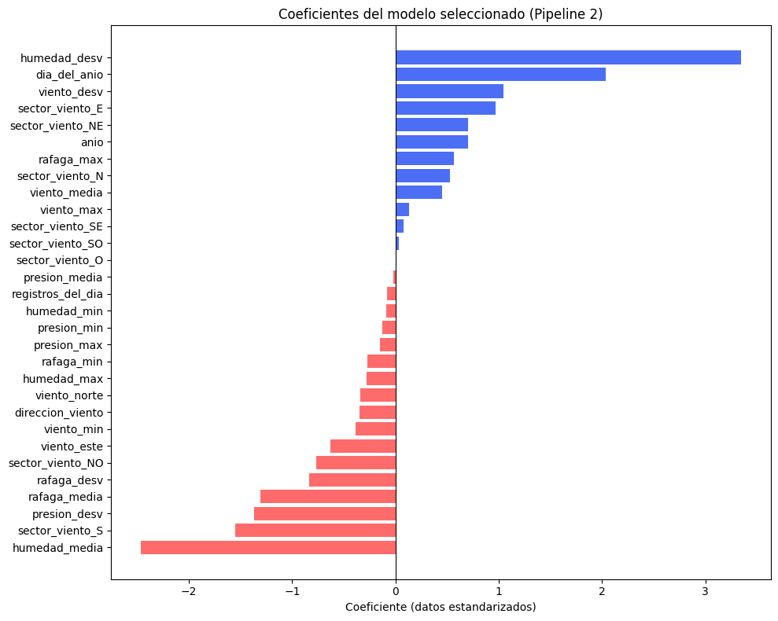

```python
# Gráfica de coeficientes (ya la construimos antes, la reutilizamos aquí como respuesta visual directa)
coef_sorted_2 = coef_df_2.sort_values('Coeficiente')
colors_2 = ['#FF6B6B' if c < 0 else '#4C6EF5' for c in coef_sorted_2['Coeficiente']]

plt.figure(figsize=(10, 8))
plt.barh(coef_sorted_2['Variable'], coef_sorted_2['Coeficiente'], color=colors_2)
plt.axvline(0, color='black', linewidth=0.8)
plt.xlabel('Coeficiente (datos estandarizados)')
plt.title('Coeficientes del modelo seleccionado (Pipeline 2)')
plt.tight_layout()
plt.show()
```

El intercepto del modelo es de **14.14**, y los coeficientes van desde **+3.34** (`humedad_desv`, el efecto positivo más fuerte) hasta **−2.46** (`humedad_media`, el efecto negativo más fuerte). Como las variables numéricas están estandarizadas (media 0, desviación 1), estos valores son comparables entre sí en magnitud: representan el cambio esperado en `temp_max_manana` (en °C) por cada aumento de una desviación estándar en la variable correspondiente, manteniendo las demás constantes. Sin embargo, como se detalla en la Pregunta 3, no todos estos coeficientes se pueden interpretar de forma confiable de manera individual, debido a la multicolinealidad detectada en la verificación de supuestos.

### 2. A partir de la tabla comparativa, ¿cuál modelo ofrece el mejor rendimiento sobre el conjunto test? ¿Qué interpretación puedes darles a los valores obtenidos sobre las métricas de rendimiento?

```python
tabla_comparativa_test
```

| Modelo | MSE | RMSE | MAE | R2 |
| --- | --- | --- | --- | --- |
| Pipeline 1 (mediana + mes) | 41.194 | 6.418 | 5.049 | 0.476 |
| Pipeline 2 (media + dia_del_anio) | 40.804 | 6.388 | 5.029 | 0.481 |

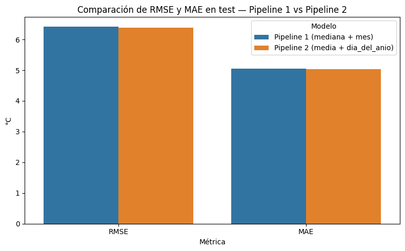

```
R² Pipeline 1 (test): 0.476
R² Pipeline 2 (test): 0.481
```

```python
# Gráfica comparativa de las 3 métricas entre los dos pipelines
metricas_plot = tabla_comparativa_test[['RMSE', 'MAE']].reset_index()
metricas_plot_melted = metricas_plot.melt(id_vars='Modelo', var_name='Métrica', value_name='Valor')

plt.figure(figsize=(8, 5))
sns.barplot(data=metricas_plot_melted, x='Métrica', y='Valor', hue='Modelo')
plt.title('Comparación de RMSE y MAE en test — Pipeline 1 vs Pipeline 2')
plt.ylabel('°C')
plt.tight_layout()
plt.show()

print(f"R² Pipeline 1 (test): {tabla_comparativa_test.loc['Pipeline 1 (mediana + mes)', 'R2']}")
print(f"R² Pipeline 2 (test): {tabla_comparativa_test.loc['Pipeline 2 (media + dia_del_anio)', 'R2']}")
```

El **Pipeline 2** (imputación por media + `dia_del_anio` numérico) ofrece el mejor rendimiento sobre el conjunto de prueba: RMSE de 6.388 (vs. 6.418), MAE de 5.029 (vs. 5.049) (estos valores estan en grados celsius) y R² de 0.481 (vs. 0.476). La diferencia es pequeña pero consistente en las tres métricas, y se logra con menos variables de entrada (30 vs. 41), lo que además reduce el riesgo de sobreajuste.

**Interpretación de las métricas:**

- **RMSE (6.39 C)**: en promedio, el error de predicción tiene una magnitud de 6.4 C (aproximado), con más peso relativo a errores grandes (por el término al cuadrado). Es un margen amplio si se piensa en aplicaciones de alerta temprana.
- **MAE (5.03 C)**: en promedio, cada predicción individual se equivoca por 5 C respecto al valor real, sin importar la dirección del error. Es más fácil de comunicar a AlpesPlanck que el RMSE porque está en las mismas unidades y no penaliza tanto los errores extremos.
- **R² (0.48)**: el modelo explica cerca de la mitad de la variabilidad de la temperatura máxima del día siguiente a partir de las variables meteorológicas del día actual. El resto de la variabilidad depende de factores no incluidos en el dataset (temperatura de días previos, condiciones en zonas vecinas, fenómenos de mayor escala como El Niño/La Niña).
- Las métricas de test son iguales o mejores que las de train en ambos pipelines, lo que descarta sobreajuste: el modelo generaliza de forma consistente a datos que no vio durante el entrenamiento.

### 3. ¿Cuáles variables fueron seleccionadas con el modelo seleccionado? A partir de estas, ¿qué interpretación de cara al problema puedes dar? Reflexiona sobre cómo este nuevo conocimiento podría ayudar a tomar decisiones en el contexto del problema.

```python
# Filtramos solo las variables "confiables" (VIF bajo) para destacar cuáles sí interpretamos
variables_confiables = tabla_importancia[
    tabla_importancia['Confiabilidad_individual'] == 'Confiable (VIF < 5)'
].sort_values('Importancia_abs', ascending=False)

variables_confiables[['Variable', 'Coeficiente', 'VIF']].head(8)
```

|  | Variable | Coeficiente | VIF |
| --- | --- | --- | --- |
| 2 | dia_del_anio | 2.035818 | 1.074897 |
| 3 | sector_viento_S | -1.553379 | 1.733845 |
| 4 | presion_desv | -1.365859 | 3.130524 |
| 5 | rafaga_media | -1.310228 | 4.831808 |
| 7 | sector_viento_E | 0.969074 | 1.290609 |
| 9 | sector_viento_NO | -0.766771 | 1.349473 |
| 10 | sector_viento_NE | 0.705218 | 4.467024 |
| 11 | anio | 0.702485 | 1.026806 |

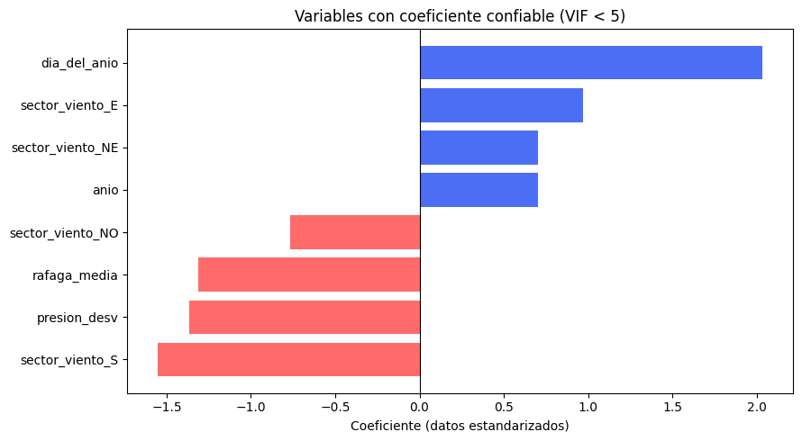

```python
plt.figure(figsize=(9, 5))
top_confiables = variables_confiables.head(8).sort_values('Coeficiente')
colors_conf = ['#FF6B6B' if c < 0 else '#4C6EF5' for c in top_confiables['Coeficiente']]
plt.barh(top_confiables['Variable'], top_confiables['Coeficiente'], color=colors_conf)
plt.axvline(0, color='black', linewidth=0.8)
plt.title('Variables con coeficiente confiable (VIF < 5)')
plt.xlabel('Coeficiente (datos estandarizados)')
plt.tight_layout()
plt.show()
```

El modelo usa 30 variables (todas las meteorológicas numéricas del día, `anio`, `dia_del_anio` y las 8 categorías de `sector_viento`), pero no todas se pueden interpretar con la misma confianza individual: como se explicó en la verificación de supuestos, la multicolinealidad (VIF > 10 en `viento_desv`, `rafaga_desv`, `presion_min`, `presion_max`) impide aislar el efecto individual de esas variables, aunque sí contribuyen en conjunto a la predicción.

**Las variables más defendibles de interpretar son `presion_desv` y `rafaga_media`** (VIF bajo, signo consistente entre el coeficiente multivariado y la correlación simple con el target): mayor variabilidad de presión atmosférica y vientos más fuertes durante el día se asocian con una temperatura máxima menor al día siguiente. Físicamente esto es coherente — presión inestable y ráfagas fuertes suelen acompañar frentes o sistemas de baja presión que traen aire más fresco, mientras que presión estable se asocia a cielos despejados y temperaturas más altas.

**Para la toma de decisiones de AlpesPlanck**: estas dos variables podrían usarse como señales tempranas de alerta — un día con alta variabilidad de presión o ráfagas fuertes es un indicio de que la temperatura del día siguiente probablemente baje, lo cual es información útil para anticipar cambios bruscos de clima relacionados con incendios forestales (menor riesgo si baja la temperatura) o para contextualizar patrones asociados a El Niño/La Niña. Sin embargo, dado que el modelo completo solo explica alrededor del 48% de la variabilidad, recomendamos a AlpesPlanck usar estas variables como un insumo complementario dentro de un sistema de predicción más amplio, no como única fuente de decisión.

### 4. A partir del contexto y los datos compartidos, ¿cómo representar la regresión lineal de forma matemática? Indique el método utilizado y el proceso para resolverlo.

El modelo de regresión lineal múltiple se representa como:

$$\hat{y} = \beta_0 + \beta_1 x_1 + \beta_2 x_2 + \dots + \beta_p x_p$$

donde $\hat{y}$ es la temperatura máxima estimada para el día siguiente (`temp_max_manana`), $\beta_0$ es el intercepto (14.14 en nuestro modelo), $x_1, \dots, x_p$ son las 30 variables predictoras del Pipeline 2 (ya imputadas, escaladas y codificadas), y $\beta_1, \dots, \beta_p$ sus coeficientes asociados.

**Método de resolución**: Mínimos Cuadrados Ordinarios (OLS), implementado por `LinearRegression()` de scikit-learn. Busca el vector de coeficientes $\boldsymbol{\beta}$ que minimiza la suma de los residuos al cuadrado entre los valores reales y los predichos:

$$\min_{\boldsymbol{\beta}} \sum_{i=1}^{n} (y_i - \hat{y}_i)^2$$

Este problema tiene solución cerrada mediante álgebra lineal:

$$\boldsymbol{\beta} = (X^T X)^{-1} X^T y$$

donde $X$ es la matriz de diseño (nuestras 30 variables predictoras ya transformadas por el pipeline) y $y$ es el vector de la variable objetivo (`temp_max_manana`).

### 5. En el ciclo de machine learning ¿Qué tipos de sesgo podría afectar los resultados y por qué? Describe dos tipos de sesgo.

**1. Sesgo de muestra:** los datos provienen de una única estación meteorológica (Jena, Alemania). El modelo aprende relaciones específicas al clima de esa región, por lo que no necesariamente generalizaría a otras ubicaciones geográficas con patrones climáticos distintos (zonas tropicales, costeras, de montaña, etc.). Si AlpesPlanck quisiera aplicar este modelo a otra estación sin reentrenarlo, correría el riesgo de predicciones poco confiables.

**2. Sesgo de medición:** durante la etapa de calidad de datos encontramos múltiples problemas sistemáticos en la forma en que se capturaron las variables: columnas `_min`/`_max` invertidas en presión, humedad, viento y ráfaga; valores de humedad registrados en escala de fracción (0-1) en vez de porcentaje; signos invertidos en `rafaga_desv`; y valores centinela (`-9999`) usados para marcar errores de sensor. Aunque corregimos los patrones sistemáticos que logramos identificar, es probable que persistan errores de medición más sutiles que no se pudieron detectar con las reglas aplicadas (por ejemplo, pequeños desfaces de calibración de los sensores que no generan una violación evidente de rango o de consistencia interna). Este tipo de sesgo afecta directamente la calidad de las variables predictoras y, por tanto, la confiabilidad de los coeficientes estimados, independientemente de qué tan bien esté especificado el modelo.

## Uso de herramientas de IA generativa

**Herramienta utilizada:** Claude (Anthropic), asistente de IA conversacional, usado a través de la interfaz de chat de Claude.ai a lo largo de todo el desarrollo del laboratorio.

**Tipo de uso:** generación inicial de código (mapeos de categorías, correcion en la construcción de pipelines de scikit-learn y pruebas estadísticas de supuestos), depuración de errores, explicación conceptual (data leakage, diferencia entre `fit()` y `fit_transform()` e interpretación de VIF/Shapiro-Wilk/Breusch-Pagan/Durbin-Watson/ Rainbow).

### Prompts principales utilizados

- Solicitud de ayuda para cargar el CSV en un DataFrame y depurar el `FileNotFoundError` inicial.
- Clasificación de variables en cuantitativas discretas/continuas y cualitativas ordinales/nominales a partir del diccionario de datos.
- Construcción de diccionarios de mapeo para normalizar `estacion_anio`, `mes` y `sector_viento` (errores de digitación, idiomas mezclados, mayúsculas/minúsculas).
- Estrategia para recuperar registros con estación/mes ambiguos usando `dia_del_anio` y viceversa.
- Detección y corrección de problemas de validez: valores fuera de rango, inversión sistemática de columnas `_min`/`_max`, error de escala en variables de humedad, valores centinela extremos.
- Verificación puntual sobre si ciertas correcciones (escalado, imputación dentro del pipeline) generaban *data leakage*.
- Apoyo para estructurar la verificación de los 5 supuestos de regresión lineal (P4.2) y la interpretación de coeficientes cruzada con VIF.
- Redacción de la sección de Análisis de Resultados (redacto mejor nuestras respuestas)

### Análisis crítico del resultado

- **¿Qué partes del contenido generado fueron correctas y útiles?** Alguna parte del código de limpieza (mapeos de categorías, detección de swaps `min`/`max`) funcionó correctamente y fue la base de todo el trabajo. También fue útil la explicación de por qué la imputación y el escalado deben ajustarse solo con `X_train` para evitar *data leakage*.
- **¿Qué decisiones técnicas fueron modificadas respecto a la respuesta de la IAG y por qué?** Cuestionamos directamente si construir `data_1`/`data_2` como copias pre-imputadas del dataset completo (como se penso inicialmente) generaría fuga de información; a partir de esa duda, se ajustó el enfoque para imputar dentro del pipeline y solo sobre train. También pusimos a prueba con código propio si usar `.fit()` sobre el pipeline completo (en vez de `.fit_transform()` + `.fit()` por separado, como se hace en la práctica P4.1) generaba algún riesgo — la IA lo explicó primero de forma teórica, pero terminamos de confirmarlo nosotros al intentar ejecutar `fit_transform()` directamente sobre el pipeline con modelo incluido, lo cual arrojó un error que evidenció por qué esa forma no aplicaba aquí.
- **¿Qué conceptos del curso permitieron evaluar o mejorar la respuesta generada?** El concepto de data leakage visto en la práctica P4.1 (imputación y escalado ajustados solo con train) nos permitió cuestionar dos veces distintas decisiones de la IA antes de aceptarlas.

### Nuestro rol

- Definimos la estrategia de trabajo del laboratorio (dividir en dos datasets/pipelines con estrategias de imputación distintas) antes de pedirle a la IA que la implementara.
- Decidimos, con criterio propio, cuándo un valor fuera de rango se corregía (`clip`, `abs`, intercambio de columnas) y cuándo se eliminaba, incluyendo el umbral de "menos de 50 registros" para descartar en vez de imputar.
- Cuestionamos y verificamos las explicaciones de la IA sobre *data leakage* en dos momentos distintos del proceso, en vez de aceptarlas de forma automática.
- Decidimos mantener `mes` (en lugar de `estacion_anio`) como variable categórica del Pipeline 1 tras evaluar el trade-off de granularidad propuesto por la IA.
- Corregimos la taxonomía de sesgos usada en el análisis de resultados para ajustarla a las categorías vistas específicamente en el curso.
- Revisamos e interpretamos todos los resultados numéricos (coeficientes, métricas, p-values de los supuestos) contrastándolos con el contexto físico del problema de AlpesPlanck, en lugar de reproducir la interpretación generada por la IA sin verificarla.

# Probemos con Datos Test Lab 1

```python
datos_test_final = pd.read_csv('data/Datos Test Lab 1.csv', sep=',')

# Parseamos la fecha con su formato real (día.mes.año), solo para dejarla legible en la salida
datos_test_final['fecha'] = pd.to_datetime(datos_test_final['fecha'], format='%d.%m.%Y')

# Generamos las predicciones con el mejor modelo
predicciones_test = pipeline_2.predict(datos_test_final)
datos_test_final['temp_max_manana'] = predicciones_test

print(f"Predicciones generadas: {len(predicciones_test)}")
print(f"Rango: {predicciones_test.min():.2f} a {predicciones_test.max():.2f} °C")
datos_test_final[['fecha', 'temp_max_manana']].head(10)
```

```
Predicciones generadas: 364
Rango: -0.27 a 29.65 °C
```

|  | fecha | temp_max_manana |
| --- | --- | --- |
| 0 | 2016-01-01 | 1.557980 |
| 1 | 2016-01-02 | 3.358081 |
| 2 | 2016-01-03 | 3.303651 |
| 3 | 2016-01-04 | 6.853363 |
| 4 | 2016-01-05 | 3.101819 |
| 5 | 2016-01-06 | 2.707154 |
| 6 | 2016-01-07 | 3.833822 |
| 7 | 2016-01-08 | 12.871100 |
| 8 | 2016-01-09 | 4.141466 |
| 9 | 2016-01-10 | 8.098242 |

```python
# Exportamos el archivo en la misma carpeta del notebook, para no sobrescribir el archivo original
datos_test_final.to_csv('Datos Test Lab 1.csv', index=False)
print("Archivo 'Datos Test Lab 1.csv' exportado correctamente (entregable final).")
```

```
Archivo 'Datos Test Lab 1.csv' exportado correctamente (entregable final).
```

### Link a video del laboratorio y agradecimiento

En esta parte dejamos el link al video que nos pide el enunciado:

- https://youtu.be/TIEMC4qr174

A la persona que vea esto, te queremos agradecer por tener la paciencia de ver todo este trabajo, creemos que nos quedo bastante extenso, pero de buena calidad, ojala asi sea y sea de tu agrado. Gracias por tu tiempo :D